# Voicing and Gemination - Mixed Effects Modelling

Jalal Al-Tamimi

Newcastle University

17 July 2018

# 1 Introduction

This analysis accompanies the article “Al-Tamimi, J. and Khattab, G., (2018). *Acoustic correlates of the voicing contrast in Lebanese Arabic singleton and geminate plosives*. Invited manuscript for the special issue of Journal of Phonetics,”Marking 50 Years of Research on Voice Onset Time and the Voicing Contrast in the World’s Languages" (eds., T. Cho, G. Docherty & D. Whalen). DOI: https://doi.org/10.1016/j.wocn.2018.09.010

This notebook presents the analyses and results of the Linear Mixed Effects Modelling that was used as a confirmatory analysis. The aim was to evaluate the relationship between each of the 19 acoustic correlates (outcome) and the six predictors.

# 2 Description of the data

19 acoustic correlates were looked at here to evaluate their impact on the four-way contrast between voicing and gemination, i.e., Voiced Singleton, Voiceless Singleton, Voiced Geminate and Voiceless Geminate. The 19 acoustic correlates used included 6 durational, three voicing, and 10 non-temporal including f0, F1 and harmonic differences. This Notebook looked at how each *individual* acoustic correlate was associated with the predictors. The next notebook extends the analysis by looking at the *combination* of these acoustic correlates and their predictive power in discriminating between the four categories above [see notebook](https://jalalal-tamimi.github.io/R-Voicing-Gemination-VOT/Voicing%20and%20Gemination%20-%20Random%20Forests.nb.html).

# 3 Loading required packages

We start by loading the required packages.

```r
requiredPackages = c('dplyr','lme4','lmerTest','emmeans','ggplot2')
for(p in requiredPackages){
  if(!require(p,character.only = TRUE)) install.packages(p)
  library(p,character.only = TRUE)
}
```

# 4 Preprocessing the data

## 4.1 Reading in the data

We start reading in the data and checking the structure.

```r
geminationRes <- read.csv("resultsGemination.csv")
str(geminationRes)
```

```
'data.frame':   7172 obs. of  28 variables:
 $ file_name         : Factor w/ 68 levels "01_F_W_main_1.wav",..: 1 1 1 1 4 4 4 4 7 7 ...
 $ speaker           : Factor w/ 20 levels "sp1","sp10","sp11",..: 1 1 1 1 3 3 3 3 12 12 ...
 $ sex               : Factor w/ 2 levels "F","M": 1 1 1 1 2 2 2 2 1 1 ...
 $ Number            : int  364 365 366 367 2379 2380 2381 2382 4373 4374 ...
 $ wordTarget        : Factor w/ 98 levels "2aabbeh","2aabeD",..: 1 1 1 1 1 1 1 1 1 1 ...
 $ word              : Factor w/ 331 levels "2AAbaD","2aabbeh",..: 2 2 2 2 54 54 54 54 54 54 ...
 $ singGem           : Factor w/ 2 levels "geminate","singleton": 1 1 1 1 1 1 1 1 1 1 ...
 $ syllType          : Factor w/ 2 levels "iambic","trochaic": 2 2 2 2 2 2 2 2 2 2 ...
 $ vowelLength       : Factor w/ 2 levels "longV1","shortV1": 1 1 1 1 1 1 1 1 1 1 ...
 $ syllStruct        : Factor w/ 5 levels "V1C2V2","V1CC2V2",..: 5 5 5 5 5 5 5 5 5 5 ...
 $ c.v               : Factor w/ 7 levels "BVOT","C2","CC2",..: 6 3 1 5 6 3 1 5 6 3 ...
 $ phoneme           : Factor w/ 17 levels "a","aa","b","bb",..: 2 4 4 10 11 4 4 10 11 4 ...
 $ modeArticulation4 : Factor w/ 1 level "stop": 1 1 1 1 1 1 1 1 1 1 ...
 $ placeArticulation : Factor w/ 4 levels "alveolar","bilabial",..: 2 2 2 2 2 2 2 2 2 2 ...
 $ voiced.unvoiced   : Factor w/ 2 levels "voiced","voiceless": 1 1 1 1 1 1 1 1 1 1 ...
 $ placeVoicing      : Factor w/ 6 levels "alveolar voiced",..: 3 3 3 3 3 3 3 3 3 3 ...
 $ duration          : num  139.9 165.5 18.5 128.9 158.1 ...
 $ durationBurst     : num  NA NA 4 NA NA NA 5 NA NA NA ...
 $ durationAsp       : num  NA NA 15 NA NA NA 6 NA NA NA ...
 $ durationVoicedPerc: num  NA 46.4 0 NA NA ...
 $ f0Onset           : num  NA 216 NA 247 NA ...
 $ f0Offset          : num  218 NA 248 NA 120 ...
 $ intensityOnset    : num  68.3 60.7 45.4 66.5 73 ...
 $ intensityOffset   : num  61.8 42.5 63.8 67.7 74.6 ...
 $ f1Onset           : num  NA NA NA 427 NA ...
 $ f1Offset          : num  619 NA NA NA 462 ...
 $ h1mnh2OnsetNorm   : num  NA NA NA 1.9 NA ...
 $ h1mnh2OffsetNorm  : num  3.79 NA NA NA 2.69 ...
```

## 4.2 Reordering of levels of predictors

Various predictors are available in data-frame, and we are interested in the impact of the following predictors: 1. Voicing: Voiced vs Voiceless 2. Gemination: Singleton vs Geminate 3. Sex: Male vs Female 4. (Preceding) Vowel Length: Short vs Long 5. Syllable Type: Iambic vs Trochaic 6. Place of Articulation: Bilabial, Alveolar, (Alveolar-)Pharyngealised and Velar

```r
# using "dplyr"
levels(geminationRes$voiced.unvoiced)
```

```
[1] "voiced"    "voiceless"
```

```r
geminationRes$voiced.unvoiced <- factor(geminationRes$voiced.unvoiced,
                                        levels = c("voiceless","voiced"))
levels(geminationRes$voiced.unvoiced)
```

```
[1] "voiceless" "voiced"
```

```r
levels(geminationRes$singGem)
```

```
[1] "geminate"  "singleton"
```

```r
geminationRes$singGem <- factor(geminationRes$singGem,
                                levels = c("singleton","geminate"))
levels(geminationRes$singGem)
```

```
[1] "singleton" "geminate"
```

```r
levels(geminationRes$sex)
```

```
[1] "F" "M"
```

```r
# no change
levels(geminationRes$vowelLength)
```

```
[1] "longV1"  "shortV1"
```

```r
geminationRes$vowelLength <- factor(geminationRes$vowelLength,
                                    levels = c("shortV1","longV1"))
levels(geminationRes$vowelLength)
```

```
[1] "shortV1" "longV1"
```

```r
levels(geminationRes$syllType)
```

```
[1] "iambic"   "trochaic"
```

```r
geminationRes$syllType <- factor(geminationRes$syllType,
                                 levels = c("trochaic","iambic"))
levels(geminationRes$syllType)
```

```
[1] "trochaic" "iambic"
```

```r
levels(geminationRes$placeArticulation)
```

```
[1] "alveolar"       "bilabial"       "pharyngealised" "velar"
```

```r
geminationRes$placeArticulation <- factor(geminationRes$placeArticulation,
                                   levels = c("bilabial","alveolar","pharyngealised","velar"))
levels(geminationRes$placeArticulation)
```

```
[1] "bilabial"       "alveolar"       "pharyngealised" "velar"
```

## 4.3 Contrast coding and centring of factor level

In our study, we wanted to use a model that allows for a meaningful interpretation of the coefficients and of the intercept. For this, we used contrast coding on all fixed effects by centring them to values between -0.5 and 0.5. With contrast coding, the Intercept is equal to the weighted average across all predictors, and all the coefficients for predictors will be equal to main effects rather than simple effects.

With this centring, our models will show the overall change from the level assigned the *negative* value to the level with the *positive* value. E.g., with voicing, voiceless was assigned -0.5 and voiced 0.5. In our statistical model the overall effect **voicing** will be shown as a change from voiceless to voiced (see article for more details).

```r
# using "dplyr"
# for change from Voiceless to Voiced
geminationRes <- mutate(geminationRes,
                        voiced.unvoiced_c = ifelse(voiced.unvoiced == 'voiced', 0.5, -0.5))
# for change from Singleton to Geminate
geminationRes <- mutate(geminationRes,
                        singGem_c = ifelse(singGem == 'geminate', 0.5, -0.5))
# for change from Male to Female
geminationRes <- mutate(geminationRes,
                        sex_c = ifelse(sex == 'F', 0.5, -0.5))
# for change from Short V1 to Long V1
geminationRes <- mutate(geminationRes,
                        vowelLength_c = ifelse(vowelLength == 'longV1', 0.5, -0.5))
# for change from Trochaic to Iambic
geminationRes <- mutate(geminationRes,
                        syllType_c = ifelse(syllType == 'iambic', 0.5, -0.5))
# for change from Bilabial, to Alveolar to (Alveolar-)Pharyngealised to Velar
geminationRes <-  mutate(geminationRes, place_c = ifelse(placeArticulation == 'velar', 0.5,
                                                                ifelse(placeVoicing =='pharyngealised', 0.133,
                                                                                     ifelse(placeVoicing == 'alveolar', -0.133,-0.5))))
```

## 4.4 Creating four new data-frames

Here we create four new datasets that are subsets of the original dataset. The aim is to have specific data-frames for each of the preceding vowel (V1), medial consonant (CD), Release phase (BVOT) and following vowel (V2). V1 can be either short or long (V1, VV1); CD can be short or long (C2, CC2).

```r
l <- c("a","aa", "e", "ee")
l2 <- c("V2", "VV2")
l3 <- c("V1", "VV1")
l4 <- c("C2","CC2")
l5 <- "BVOT"
geminationVowels <- filter(geminationRes, phoneme %in% l)
geminationV2 <- filter(geminationVowels, c.v %in% l2)
geminationV1 <- filter(geminationVowels, c.v %in% l3)
geminationCons <- filter(geminationRes, c.v %in% l4)
geminationVOT <- filter(geminationRes, c.v %in% l5)
```

## 4.5 Creating a new outcome (VOT)

In our original submission, we used the proportion of voicing in both the closure and release phases based the computations we developed [see here](https://github.com/JalalAl-Tamimi/Praat-Voicing-detection). This proportion of voicing aims at explaining the patterns of passive devoicing and/or active voicing in the voicing by gemination contrasts. We also wanted to look at the voicing patterns in the voicing by gemination contrasts following the traditional “VOT” notion. Hence we computed the “VOT” by following the revised procedure as described in Abramson, A.S. & Whalen, D. (2017) (https://doi.org/10.1016/j.wocn.2017.05.002). Below is the implementation of this method based on our computations of the proportion of voicing in both closure and release phases. We use the threshold of 50% voicing; if “voicing” is equal or is higher than 50%, the total duration of the closure is considered negative VT, otherwise, the VOT is positive and is equivalent to the total duration of the Release phase (i.e., burst, and aspiration).

```r
# start by creating a new predictor
geminationCons$VOTDec <- NA
x <- -geminationCons$duration
y <- geminationVOT$duration
# below, we use the same threshold
geminationCons$VOTDec <- ifelse(geminationCons$durationVoicedPerc >= 50,
       x,y)
```

# 5 Running our Linear Mixed Effects Models

Now that the preprocessing of the data finished, we start with our modelling. As a remonder, our aim is to use these analyses in a confirmatory manner. We aim to evaluate the effects of the six predictors described above on each of the acoustic correlates. Crossed random effects were used for speaker and items.

For all models below, we used a combination of models: fixed effects only; random intercepts; random intercepts and slopes; interactions for the fixed effects; interactions for the slopes; etc. The optimal model in each case was the one presented below and had the following structure:

1. Fixed effects with no interactions
2. Random Intercepts for items
3. Random Intercepts and Slopes for speaker (for all fixed effects minus sex). These random slopes were all *within* subjects, and were necessary to allow speakers to co-vary with respect to their effects. These random slopes were decorrelated from the Intercept (by using ||).

After each model was run, we compared models with an intercept only model (i.e., without the fixed effects). This is used to provide the statistical significance of our model. We are also using the package “lmerTest” to display the p values of each predictor. This uses an approximation of the degrees of freedom, and allows us to obtain estimated p values. This may be problematic given that these are approximations, and thus it is always best to evaluate the significance levels of our predictors using model comparisons.

We evaluate model’s residuals, and then we present the optimal models’ summaries. We then use the “predict” function from “lme4” to obtain the fitted values that take into account both fixed and random effects structure. The fitted (or predicted) values are adjusted by our statistical model and are then used in the figures.

## 5.1 Duration (msec)

Within duration, we computed the durations of the vowel preceding the consonant (V1), the medial consonant (CD), Release Phase (Rel), Burst Phase (B), Aspiration Phase (Asp) and the vowel following the consonant (V2)

### 5.1.1 Duration of the preceding vowel (V1)

#### 5.1.1.1 Model specification

We run three models. For model comparisons, we are required to use Maximum Likelihood (ML) on both Optimal and Null models (by adding REML=F). Then we run a second Optimal models with Restricted Maximum Likelihood (REML), to obtain the coefficients (by adding REML=T)

##### 5.1.1.1.1 Optimal model (ML)

```r
durationV1.xmdl.Full.M <- lmer(duration~voiced.unvoiced_c+singGem_c+sex_c+vowelLength_c+syllType_c+place_c+
                                (voiced.unvoiced_c+singGem_c+vowelLength_c+syllType_c+place_c||speaker)+(1|wordTarget),
                              data = geminationV1,na.action=na.exclude,
                              REML=F,
                              control = lmerControl(optimizer = "bobyqa",optCtrl=list(maxfun=1e5)))
```

##### 5.1.1.1.2 Optimal model (REML)

```r
durationV1.xmdl.Full.R <- lmer(duration~voiced.unvoiced_c+singGem_c+sex_c+vowelLength_c+syllType_c+place_c+
                                (voiced.unvoiced_c+singGem_c+vowelLength_c+syllType_c+place_c||speaker)+(1|wordTarget),
                              data = geminationV1,na.action=na.exclude,
                              REML=T,
                              control = lmerControl(optimizer = "bobyqa",optCtrl=list(maxfun=1e5)))
```

##### 5.1.1.1.3 Null model (ML)

```r
durationV1.xmdl.Null.M <- lmer(duration~1+
                                (voiced.unvoiced_c+singGem_c+vowelLength_c+syllType_c+place_c||speaker)+(1|wordTarget),
                              data = geminationV1,na.action=na.exclude,
                              REML=F,
                              control = lmerControl(optimizer = "bobyqa",optCtrl=list(maxfun=1e5)))
```

#### 5.1.1.2 Results of our model

##### 5.1.1.2.1 Model comparisons

```r
anova(durationV1.xmdl.Null.M,durationV1.xmdl.Full.M)
```

```
Data: geminationV1
Models:
durationV1.xmdl.Null.M: duration ~ 1 + (voiced.unvoiced_c + singGem_c + vowelLength_c +
durationV1.xmdl.Null.M:     syllType_c + place_c || speaker) + (1 | wordTarget)
durationV1.xmdl.Full.M: duration ~ voiced.unvoiced_c + singGem_c + sex_c + vowelLength_c +
durationV1.xmdl.Full.M:     syllType_c + place_c + (voiced.unvoiced_c + singGem_c + vowelLength_c +
durationV1.xmdl.Full.M:     syllType_c + place_c || speaker) + (1 | wordTarget)
                       Df   AIC   BIC  logLik deviance  Chisq Chi Df
durationV1.xmdl.Null.M  9 15286 15335 -7633.9    15268
durationV1.xmdl.Full.M 15 15162 15244 -7566.0    15132 135.82      6
                       Pr(>Chisq)
durationV1.xmdl.Null.M
durationV1.xmdl.Full.M  < 2.2e-16 ***
---
Signif. codes:  0 ‘***’ 0.001 ‘**’ 0.01 ‘*’ 0.05 ‘.’ 0.1 ‘ ’ 1
```

As can be seen, our optimal model improved the model fit.

##### 5.1.1.2.2 Residuals

We inspect our model below, by looking at the residuals. There are minor deviations observed, due to the nature of our data.

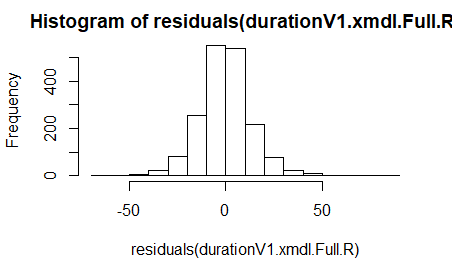

```r
hist(residuals(durationV1.xmdl.Full.R))
```

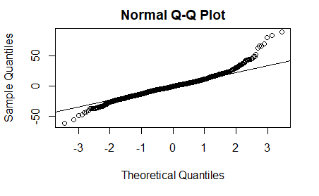

```r
qqnorm(residuals(durationV1.xmdl.Full.R)); qqline(residuals(durationV1.xmdl.Full.R))
```

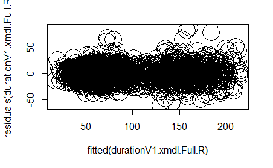

```r
plot(fitted(durationV1.xmdl.Full.R),residuals(durationV1.xmdl.Full.R), cex = 4)
```

##### 5.1.1.2.3 Summary of model

```r
summary(durationV1.xmdl.Full.R)
```

```
Linear mixed model fit by REML. t-tests use Satterthwaite's method [
lmerModLmerTest]
Formula:
duration ~ voiced.unvoiced_c + singGem_c + sex_c + vowelLength_c +
    syllType_c + place_c + (voiced.unvoiced_c + singGem_c + vowelLength_c +
    syllType_c + place_c || speaker) + (1 | wordTarget)
   Data: geminationV1
Control:
lmerControl(optimizer = "bobyqa", optCtrl = list(maxfun = 1e+05))

REML criterion at convergence: 15102

Scaled residuals:
    Min      1Q  Median      3Q     Max
-4.2034 -0.5417 -0.0270  0.5011  6.1062

Random effects:
 Groups     Name              Variance Std.Dev.
 wordTarget (Intercept)        99.9410  9.9970
 speaker    place_c             0.4836  0.6954
 speaker.1  syllType_c         23.0797  4.8041
 speaker.2  vowelLength_c     209.1023 14.4604
 speaker.3  singGem_c          14.8229  3.8500
 speaker.4  voiced.unvoiced_c   3.9109  1.9776
 speaker.5  (Intercept)       229.1941 15.1392
 Residual                     216.9083 14.7278
Number of obs: 1793, groups:  wordTarget, 98; speaker, 20

Fixed effects:
                  Estimate Std. Error      df t value Pr(>|t|)
(Intercept)        102.818      3.893  29.724  26.412  < 2e-16 ***
voiced.unvoiced_c   10.567      2.643  92.002   3.998 0.000129 ***
singGem_c          -10.362      2.546  93.293  -4.070 9.83e-05 ***
sex_c                4.038      6.832  17.968   0.591 0.561863
vowelLength_c       81.472      4.057  39.506  20.082  < 2e-16 ***
syllType_c         -14.920      3.305  94.147  -4.515 1.83e-05 ***
place_c             -2.028      3.427  88.501  -0.592 0.555494
---
Signif. codes:  0 ‘***’ 0.001 ‘**’ 0.01 ‘*’ 0.05 ‘.’ 0.1 ‘ ’ 1

Correlation of Fixed Effects:
            (Intr) vcd.n_ sngGm_ sex_c  vwlLn_ syllT_
vocd.nvcd_c  0.091
singGem_c   -0.123 -0.034
sex_c       -0.001  0.001  0.001
vowlLngth_c  0.098 -0.089  0.045  0.000
syllType_c   0.282  0.036 -0.343 -0.001  0.162
place_c      0.265  0.527 -0.012  0.000 -0.035  0.029
```

#### 5.1.1.3 Figures

The figure presented below, uses the predicted (or fitted) values; these are the values *adjusted* by the statistical model. These take into account the random effects’ structure as well as the fixed effects’ structure.

##### 5.1.1.3.1 Using “predict”

The following code is used to record the predicted (or fitted) values into the same data-frame. This will then be used to plot the results of the model

```r
geminationV1$fitted_durationV1 <- predict(lmer(duration~voiced.unvoiced_c+singGem_c+sex_c+vowelLength_c+syllType_c+place_c+
                                (voiced.unvoiced_c+singGem_c+vowelLength_c+syllType_c+place_c||speaker)+(1|wordTarget),
                              data = geminationV1,na.action=na.exclude,
                              REML=T,
                              control = lmerControl(optimizer = "bobyqa",optCtrl=list(maxfun=1e5)))
)
```

##### 5.1.1.3.2 Plotting the results

We use “ggplot2” to plot the results. This will use the “predicted” (or fitted) values adjusted by our statistical model. The dashed lines *within* the boxplots are the mean values; the median is marked by the horizontal straight lines.

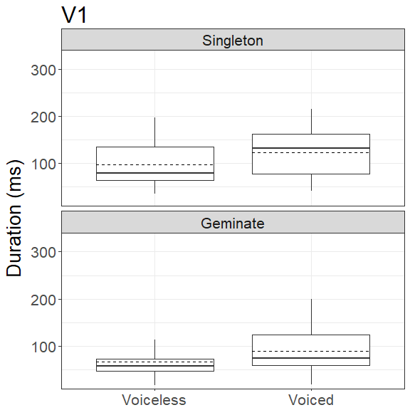

```r
labels <- c(singleton = "Singleton", geminate = "Geminate")
ggdurV1ByVoice <- ggplot(geminationV1, aes(y=fitted_durationV1, x=voiced.unvoiced)) +
  geom_boxplot(outlier.colour = "NA",na.rm=TRUE) +
  stat_summary(fun.y = mean, geom = "errorbar", aes(ymax = ..y.., ymin = ..y..),
               width = .75, linetype = "dashed") +
  ylab(expression(paste("Duration (ms)"))) + labs(title = "V1") +
  coord_cartesian(ylim = c(25,325)) +
  theme_set(theme_bw()) + theme(text=element_text(size=20)) +
  theme(axis.title.x = element_blank()) + theme(legend.title=element_blank()) +
  scale_x_discrete(breaks=levels(geminationV1$voiced.unvoiced), labels=c("Voiceless","Voiced")) +
  facet_wrap(~singGem,ncol=1,labeller=labeller(singGem = labels))
ggdurV1ByVoice
```

#### 5.1.1.4 Pairwise comparisons

After running our statistical model above, we wanted to evaluate whether the differences observed between “voicing” and “gemination” is statistically significant (or not). We present the means and standard deviations for each of the four-way contrast based on the predicted (or fitted) values.

##### 5.1.1.4.1 Descriptive statistics

The predicted means and SDs of the preceding vowel duration are provided below. As can be seen, there are already differences observed related to both “voicing” and “gemination”.

```r
# using "dplyr"
geminationV1 %>% group_by(singGem:voiced.unvoiced) %>% summarise(mean(fitted_durationV1), sd(fitted_durationV1))
```

| singGem:voiced.unvoiced | mean(fitted_durationV1) | sd(fitted_durationV1) |
| --- | --- | --- |
| singleton:voiceless | 97.90631 | 43.42403 |
| singleton:voiced | 123.25203 | 49.01312 |
| geminate:voiceless | 67.09620 | 32.53265 |
| geminate:voiced | 89.59858 | 42.91471 |

##### 5.1.1.4.2 Pairwise t-test with FDR corrections

We used the pairwise t-test as available in base R. The input was the predicted (or fitted) values as adjusted by our statistical model. It was not possible to directly use our statistical model’s output to compare models, given that our LMM model was looking at overall change as a main effect rather than as a simple effect’s model. This is why we have used the predicted (or fitted) values as adjusted by our statistical model; the results are the same if we were to use the “actual” results rather than the predicted ones. We used FDR (for False Discovery Rate) correction for multiple comparisons as this allowed for correcting for bias in the differences in doing multiple comparisons.

```r
pairwise.t.test(geminationV1$fitted_durationV1, geminationV1$singGem:geminationV1$voiced.unvoiced, p.adj = "fdr")
```

```
    Pairwise comparisons using t tests with pooled SD

data:  geminationV1$fitted_durationV1 and geminationV1$singGem:geminationV1$voiced.unvoiced

                   singleton:voiceless singleton:voiced
singleton:voiced   5.8e-16             -
geminate:voiceless < 2e-16             < 2e-16
geminate:voiced    0.005               < 2e-16
                   geminate:voiceless
singleton:voiced   -
geminate:voiceless -
geminate:voiced    4.5e-16

P value adjustment method: fdr
```

### 5.1.2 Duration of the Closure Duration (CD)

#### 5.1.2.1 Model specification

We run three models. For model comparisons, we are required to use Maximum Likelihood (ML) on both Optimal and Null models (by adding REML=F). Then we run a second Optimal models with Restricted Maximum Likelihood (REML), to obtain the coefficients (by adding REML=T)

##### 5.1.2.1.1 Optimal model (ML)

```r
durationCD.xmdl.Full.M <- lmer(duration~voiced.unvoiced_c+singGem_c+sex_c+vowelLength_c+syllType_c+place_c+
                                (voiced.unvoiced_c+singGem_c+vowelLength_c+syllType_c+place_c||speaker)+(1|wordTarget),
                              data = geminationCons,na.action=na.exclude,
                              REML=F,
                              control = lmerControl(optimizer = "bobyqa",optCtrl=list(maxfun=1e5)))
```

##### 5.1.2.1.2 Optimal model (REML)

```r
durationCD.xmdl.Full.R <- lmer(duration~voiced.unvoiced_c+singGem_c+sex_c+vowelLength_c+syllType_c+place_c+
                                (voiced.unvoiced_c+singGem_c+vowelLength_c+syllType_c+place_c||speaker)+(1|wordTarget),
                              data = geminationCons,na.action=na.exclude,
                              REML=T,
                              control = lmerControl(optimizer = "bobyqa",optCtrl=list(maxfun=1e5)))
```

##### 5.1.2.1.3 Null model (ML)

```r
durationCD.xmdl.Null.M <- lmer(duration~1+
                                (voiced.unvoiced_c+singGem_c+vowelLength_c+syllType_c+place_c||speaker)+(1|wordTarget),
                              data = geminationCons,na.action=na.exclude,
                              REML=F,
                              control = lmerControl(optimizer = "bobyqa",optCtrl=list(maxfun=1e5)))
```

#### 5.1.2.2 Results of our model

##### 5.1.2.2.1 Model comparisons

```r
anova(durationCD.xmdl.Null.M,durationCD.xmdl.Full.M)
```

```
Data: geminationCons
Models:
durationCD.xmdl.Null.M: duration ~ 1 + (voiced.unvoiced_c + singGem_c + vowelLength_c +
durationCD.xmdl.Null.M:     syllType_c + place_c || speaker) + (1 | wordTarget)
durationCD.xmdl.Full.M: duration ~ voiced.unvoiced_c + singGem_c + sex_c + vowelLength_c +
durationCD.xmdl.Full.M:     syllType_c + place_c + (voiced.unvoiced_c + singGem_c + vowelLength_c +
durationCD.xmdl.Full.M:     syllType_c + place_c || speaker) + (1 | wordTarget)
                       Df   AIC   BIC  logLik deviance  Chisq Chi Df
durationCD.xmdl.Null.M  9 15398 15447 -7689.7    15380
durationCD.xmdl.Full.M 15 15272 15355 -7621.1    15242 137.23      6
                       Pr(>Chisq)
durationCD.xmdl.Null.M
durationCD.xmdl.Full.M  < 2.2e-16 ***
---
Signif. codes:  0 ‘***’ 0.001 ‘**’ 0.01 ‘*’ 0.05 ‘.’ 0.1 ‘ ’ 1
```

As can be seen, our optimal model improved the model fit.

##### 5.1.2.2.2 Residuals

We inspect our model below, by looking at the residuals. There are minor deviations observed, due to the nature of our data.

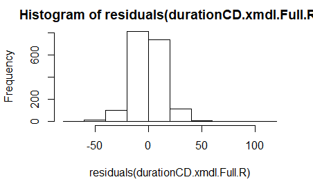

```r
hist(residuals(durationCD.xmdl.Full.R))
```

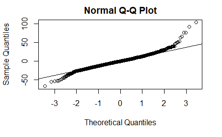

```r
qqnorm(residuals(durationCD.xmdl.Full.R)); qqline(residuals(durationCD.xmdl.Full.R))
```

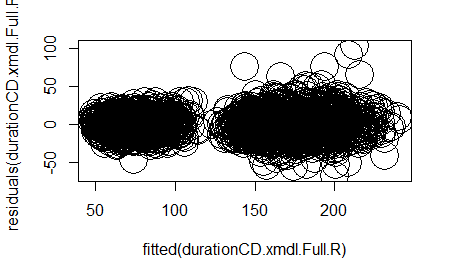

```r
plot(fitted(durationCD.xmdl.Full.R),residuals(durationCD.xmdl.Full.R), cex = 4)
```

##### 5.1.2.2.3 Summary of model

```r
summary(durationCD.xmdl.Full.R)
```

```
Linear mixed model fit by REML. t-tests use Satterthwaite's method [
lmerModLmerTest]
Formula:
duration ~ voiced.unvoiced_c + singGem_c + sex_c + vowelLength_c +
    syllType_c + place_c + (voiced.unvoiced_c + singGem_c + vowelLength_c +
    syllType_c + place_c || speaker) + (1 | wordTarget)
   Data: geminationCons
Control:
lmerControl(optimizer = "bobyqa", optCtrl = list(maxfun = 1e+05))

REML criterion at convergence: 15214.2

Scaled residuals:
    Min      1Q  Median      3Q     Max
-4.4156 -0.5681 -0.0335  0.5333  6.7738

Random effects:
 Groups     Name              Variance Std.Dev.
 wordTarget (Intercept)        44.77    6.691
 speaker    place_c            20.75    4.555
 speaker.1  syllType_c         75.48    8.688
 speaker.2  vowelLength_c      19.18    4.379
 speaker.3  singGem_c         294.82   17.170
 speaker.4  voiced.unvoiced_c  31.33    5.597
 speaker.5  (Intercept)       154.61   12.434
 Residual                     234.14   15.302
Number of obs: 1793, groups:  wordTarget, 98; speaker, 20

Fixed effects:
                  Estimate Std. Error      df t value Pr(>|t|)
(Intercept)        121.250      3.104  25.366  39.060  < 2e-16 ***
voiced.unvoiced_c  -22.568      2.251  65.416 -10.023 7.57e-15 ***
singGem_c          101.658      4.208  24.950  24.157  < 2e-16 ***
sex_c                9.818      5.669  17.818   1.732 0.100556
vowelLength_c        1.662      2.014  64.632   0.825 0.412313
syllType_c          -7.409      2.968  50.626  -2.496 0.015862 *
place_c            -10.939      2.663  72.044  -4.107 0.000104 ***
---
Signif. codes:  0 ‘***’ 0.001 ‘**’ 0.01 ‘*’ 0.05 ‘.’ 0.1 ‘ ’ 1

Correlation of Fixed Effects:
            (Intr) vcd.n_ sngGm_ sex_c  vwlLn_ syllT_
vocd.nvcd_c  0.070
singGem_c   -0.048 -0.013
sex_c       -0.002  0.000  0.001
vowlLngth_c  0.127 -0.108  0.029 -0.001
syllType_c   0.202  0.025 -0.120 -0.002  0.187
place_c      0.222  0.410 -0.005 -0.002 -0.047  0.022
```

#### 5.1.2.3 Figures

The figure presented below, uses the predicted (or fitted) values; these are the values *adjusted* by the statistical model. These take into account the random effects’ structure as well as the fixed effects’ structure.

##### 5.1.2.3.1 Using “predict”

The following code is used to record the predicted (or fitted) values into the same data-frame. This will then be used to plot the results of the model

```r
geminationCons$fitted_durationCD <- predict(lmer(duration~voiced.unvoiced_c+singGem_c+sex_c+vowelLength_c+syllType_c+place_c+
                                (voiced.unvoiced_c+singGem_c+vowelLength_c+syllType_c+place_c||speaker)+(1|wordTarget),
                              data = geminationCons,na.action=na.exclude,
                              REML=T,
                              control = lmerControl(optimizer = "bobyqa",optCtrl=list(maxfun=1e5)))
)
```

##### 5.1.2.3.2 Plotting the results

We use “ggplot2” to plot the results. This will use the “predicted” (or fitted) values adjusted by our statistical model. The dashed lines *within* the boxplots are the mean values; the median is marked by the horizontal straight lines.

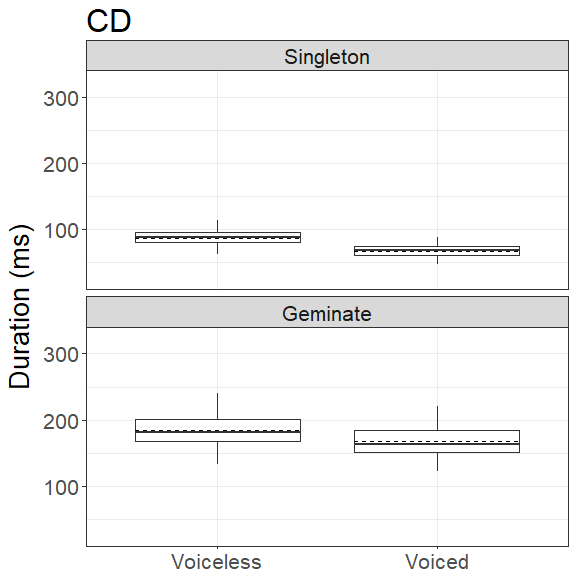

```r
labels <- c(singleton = "Singleton", geminate = "Geminate")
ggdurCDByVoice <- ggplot(geminationCons, aes(y=fitted_durationCD, x=voiced.unvoiced)) +
  geom_boxplot(outlier.colour = "NA",na.rm=TRUE) +
  stat_summary(fun.y = mean, geom = "errorbar", aes(ymax = ..y.., ymin = ..y..),
               width = .75, linetype = "dashed") +
  ylab(expression(paste("Duration (ms)"))) + labs(title = "CD") +
  coord_cartesian(ylim = c(25,325)) +
  theme_set(theme_bw()) + theme(text=element_text(size=20)) +
  theme(axis.title.x = element_blank()) + theme(legend.title=element_blank()) +
  scale_x_discrete(breaks=levels(geminationCons$voiced.unvoiced), labels=c("Voiceless","Voiced")) +
  facet_wrap(~singGem,ncol=1,labeller=labeller(singGem = labels))
ggdurCDByVoice
```

#### 5.1.2.4 Pairwise comparisons

After running our statistical model above, we wanted to evaluate whether the differences observed between “voicing” and “gemination” is statistically significant (or not). We present the means and standard deviations for each of the four-way contrast based on the predicted (or fitted) values.

##### 5.1.2.4.1 Descriptive statistics

The predicted means and SDs of the closure duration are provided below. As can be seen, there are already differences observed related to both “voicing” and “gemination”.

```r
# using "dplyr"
geminationCons %>% group_by(singGem:voiced.unvoiced) %>% summarise(mean(fitted_durationCD), sd(fitted_durationCD))
```

| singGem:voiced.unvoiced | mean(fitted_durationCD) | sd(fitted_durationCD) |
| --- | --- | --- |
| singleton:voiceless | 87.56600 | 10.748736 |
| singleton:voiced | 67.96491 | 8.981905 |
| geminate:voiceless | 184.12909 | 22.593531 |
| geminate:voiced | 167.57413 | 20.843101 |

##### 5.1.2.4.2 Pairwise t-test with FDR corrections

We used the pairwise t-test as available in base R. The input was the predicted (or fitted) values as adjusted by our statistical model. It was not possible to directly use our statistical model’s output to compare models, given that our LMM model was looking at overall change as a main effect rather than as a simple effect’s model. This is why we have used the predicted (or fitted) values as adjusted by our statistical model; the results are the same if we were to use the “actual” results rather than the predicted ones. We used FDR (for False Discovery Rate) correction for multiple comparisons as this allowed for correcting for bias in the differences in doing multiple comparisons.

```r
pairwise.t.test(geminationCons$fitted_durationCD, geminationCons$singGem:geminationCons$voiced.unvoiced, p.adj = "fdr")
```

```
    Pairwise comparisons using t tests with pooled SD

data:  geminationCons$fitted_durationCD and geminationCons$singGem:geminationCons$voiced.unvoiced

                   singleton:voiceless singleton:voiced
singleton:voiced   <2e-16              -
geminate:voiceless <2e-16              <2e-16
geminate:voiced    <2e-16              <2e-16
                   geminate:voiceless
singleton:voiced   -
geminate:voiceless -
geminate:voiced    <2e-16

P value adjustment method: fdr
```

### 5.1.3 Duration of the Release Phase (Rel)

#### 5.1.3.1 Model specification

We run three models. For model comparisons, we are required to use Maximum Likelihood (ML) on both Optimal and Null models (by adding REML=F). Then we run a second Optimal models with Restricted Maximum Likelihood (REML), to obtain the coefficients (by adding REML=T)

##### 5.1.3.1.1 Optimal model (ML)

```r
durationRel.xmdl.Full.M <- lmer(duration~voiced.unvoiced_c+singGem_c+sex_c+vowelLength_c+syllType_c+place_c+
                                (voiced.unvoiced_c+singGem_c+vowelLength_c+syllType_c+place_c||speaker)+(1|wordTarget),
                              data = geminationVOT,na.action=na.exclude,
                              REML=F,
                              control = lmerControl(optimizer = "bobyqa",optCtrl=list(maxfun=1e5)))
```

##### 5.1.3.1.2 Optimal model (REML)

```r
durationRel.xmdl.Full.R <- lmer(duration~voiced.unvoiced_c+singGem_c+sex_c+vowelLength_c+syllType_c+place_c+
                                (voiced.unvoiced_c+singGem_c+vowelLength_c+syllType_c+place_c||speaker)+(1|wordTarget),
                              data = geminationVOT,na.action=na.exclude,
                              REML=T,
                              control = lmerControl(optimizer = "bobyqa",optCtrl=list(maxfun=1e5)))
```

##### 5.1.3.1.3 Null model (ML)

```r
durationRel.xmdl.Null.M <- lmer(duration~1+
                                (voiced.unvoiced_c+singGem_c+vowelLength_c+syllType_c+place_c||speaker)+(1|wordTarget),
                              data = geminationVOT,na.action=na.exclude,
                              REML=F,
                              control = lmerControl(optimizer = "bobyqa",optCtrl=list(maxfun=1e5)))
```

#### 5.1.3.2 Results of our model

##### 5.1.3.2.1 Model comparisons

```r
anova(durationRel.xmdl.Null.M,durationRel.xmdl.Full.M)
```

```
Data: geminationVOT
Models:
durationRel.xmdl.Null.M: duration ~ 1 + (voiced.unvoiced_c + singGem_c + vowelLength_c +
durationRel.xmdl.Null.M:     syllType_c + place_c || speaker) + (1 | wordTarget)
durationRel.xmdl.Full.M: duration ~ voiced.unvoiced_c + singGem_c + sex_c + vowelLength_c +
durationRel.xmdl.Full.M:     syllType_c + place_c + (voiced.unvoiced_c + singGem_c + vowelLength_c +
durationRel.xmdl.Full.M:     syllType_c + place_c || speaker) + (1 | wordTarget)
                        Df   AIC   BIC  logLik deviance  Chisq Chi Df
durationRel.xmdl.Null.M  9 12369 12418 -6175.3    12351
durationRel.xmdl.Full.M 15 12290 12373 -6130.2    12260 90.209      6
                        Pr(>Chisq)
durationRel.xmdl.Null.M
durationRel.xmdl.Full.M  < 2.2e-16 ***
---
Signif. codes:  0 ‘***’ 0.001 ‘**’ 0.01 ‘*’ 0.05 ‘.’ 0.1 ‘ ’ 1
```

As can be seen, our optimal model improved the model fit.

##### 5.1.3.2.2 Residuals

We inspect our model below, by looking at the residuals. There are minor deviations observed, due to the nature of our data.

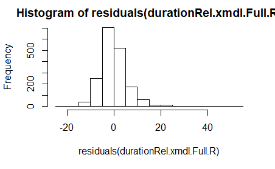

```r
hist(residuals(durationRel.xmdl.Full.R))
```

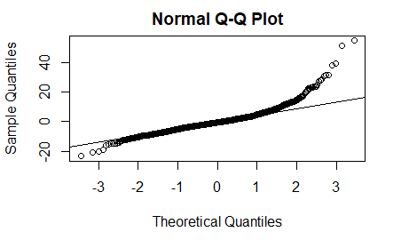

```r
qqnorm(residuals(durationRel.xmdl.Full.R)); qqline(residuals(durationRel.xmdl.Full.R))
```

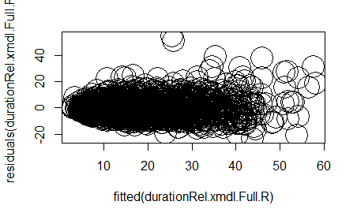

```r
plot(fitted(durationRel.xmdl.Full.R),residuals(durationRel.xmdl.Full.R), cex = 4)
```

##### 5.1.3.2.3 Summary of model

```r
summary(durationRel.xmdl.Full.R)
```

```
Linear mixed model fit by REML. t-tests use Satterthwaite's method [
lmerModLmerTest]
Formula:
duration ~ voiced.unvoiced_c + singGem_c + sex_c + vowelLength_c +
    syllType_c + place_c + (voiced.unvoiced_c + singGem_c + vowelLength_c +
    syllType_c + place_c || speaker) + (1 | wordTarget)
   Data: geminationVOT
Control:
lmerControl(optimizer = "bobyqa", optCtrl = list(maxfun = 1e+05))

REML criterion at convergence: 12244.2

Scaled residuals:
    Min      1Q  Median      3Q     Max
-3.5399 -0.5191 -0.0873  0.3942  8.2724

Random effects:
 Groups     Name              Variance Std.Dev.
 wordTarget (Intercept)       12.958   3.600
 speaker    place_c           23.041   4.800
 speaker.1  syllType_c         2.278   1.509
 speaker.2  vowelLength_c      6.832   2.614
 speaker.3  singGem_c          4.564   2.136
 speaker.4  voiced.unvoiced_c 16.655   4.081
 speaker.5  (Intercept)       21.039   4.587
 Residual                     44.108   6.641
Number of obs: 1793, groups:  wordTarget, 98; speaker, 20

Fixed effects:
                  Estimate Std. Error      df t value Pr(>|t|)
(Intercept)        24.9692     1.2494 33.1458  19.985  < 2e-16 ***
voiced.unvoiced_c  -9.3847     1.3296 53.0690  -7.058 3.61e-09 ***
singGem_c           0.3376     1.0092 77.6741   0.335    0.739
sex_c               1.6417     2.1058 17.3511   0.780    0.446
vowelLength_c       5.1409     1.0808 71.5438   4.757 9.93e-06 ***
syllType_c          1.5479     1.2070 85.8098   1.282    0.203
place_c            12.3890     1.6645 58.2555   7.443 5.15e-10 ***
---
Signif. codes:  0 ‘***’ 0.001 ‘**’ 0.01 ‘*’ 0.05 ‘.’ 0.1 ‘ ’ 1

Correlation of Fixed Effects:
            (Intr) vcd.n_ sngGm_ sex_c  vwlLn_ syllT_
vocd.nvcd_c  0.078
singGem_c   -0.133 -0.024
sex_c       -0.003  0.000  0.001
vowlLngth_c  0.157 -0.091  0.059  0.000
syllType_c   0.330  0.027 -0.327 -0.001  0.229
place_c      0.235  0.297 -0.009 -0.003 -0.037  0.023
```

#### 5.1.3.3 Figures

The figure presented below, uses the predicted (or fitted) values; these are the values *adjusted* by the statistical model. These take into account the random effects’ structure as well as the fixed effects’ structure.

##### 5.1.3.3.1 Using “predict”

The following code is used to record the predicted (or fitted) values into the same data-frame. This will then be used to plot the results of the model

```r
geminationVOT$fitted_durationRel <- predict(lmer(duration~voiced.unvoiced_c+singGem_c+sex_c+vowelLength_c+syllType_c+place_c+
                                (voiced.unvoiced_c+singGem_c+vowelLength_c+syllType_c+place_c||speaker)+(1|wordTarget),
                              data = geminationVOT,na.action=na.exclude,
                              REML=T,
                              control = lmerControl(optimizer = "bobyqa",optCtrl=list(maxfun=1e5)))
)
```

##### 5.1.3.3.2 Plotting the results

We use “ggplot2” to plot the results. This will use the “predicted” (or fitted) values adjusted by our statistical model. The dashed lines *within* the boxplots are the mean values; the median is marked by the horizontal straight lines.

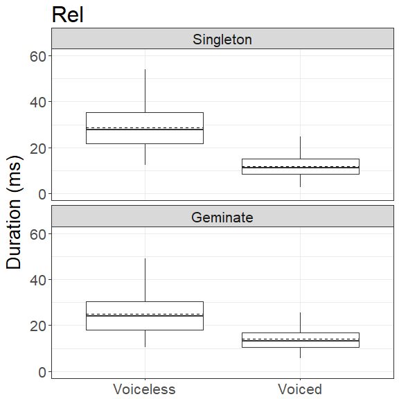

```r
labels <- c(singleton = "Singleton", geminate = "Geminate")
ggdurRelByVoice <- ggplot(geminationVOT, aes(y=fitted_durationRel, x=voiced.unvoiced)) +
  geom_boxplot(outlier.colour = "NA",na.rm=TRUE) +
  stat_summary(fun.y = mean, geom = "errorbar", aes(ymax = ..y.., ymin = ..y..),
               width = .75, linetype = "dashed") +
  ylab(expression(paste("Duration (ms)"))) + labs(title = "Rel") +
  coord_cartesian(ylim = c(0,60)) +
  theme_set(theme_bw()) + theme(text=element_text(size=20)) +
  theme(axis.title.x = element_blank()) + theme(legend.title=element_blank()) +
  scale_x_discrete(breaks=levels(geminationVOT$voiced.unvoiced), labels=c("Voiceless","Voiced")) +
  facet_wrap(~singGem,ncol=1,labeller=labeller(singGem = labels))
ggdurRelByVoice
```

#### 5.1.3.4 Pairwise comparisons

After running our statistical model above, we wanted to evaluate whether the differences observed between “voicing” and “gemination” is statistically significant (or not). We present the means and standard deviations for each of the four-way contrast based on the predicted (or fitted) values.

##### 5.1.3.4.1 Descriptive statistics

The predicted means and SDs of the duration of the release phase are provided below. As can be seen, there are already differences observed related to both “voicing” and “gemination”.

```r
# using "dplyr"
geminationVOT %>% group_by(singGem:voiced.unvoiced) %>% summarise(mean(fitted_durationRel), sd(fitted_durationRel))
```

| singGem:voiced.unvoiced | mean(fitted_durationRel) | sd(fitted_durationRel) |
| --- | --- | --- |
| singleton:voiceless | 28.62206 | 9.443816 |
| singleton:voiced | 11.89487 | 4.839687 |
| geminate:voiceless | 25.06323 | 8.971457 |
| geminate:voiced | 13.95754 | 4.588810 |

##### 5.1.3.4.2 Pairwise t-test with FDR corrections

We used the pairwise t-test as available in base R. The input was the predicted (or fitted) values as adjusted by our statistical model. It was not possible to directly use our statistical model’s output to compare models, given that our LMM model was looking at overall change as a main effect rather than as a simple effect’s model. This is why we have used the predicted (or fitted) values as adjusted by our statistical model; the results are the same if we were to use the “actual” results rather than the predicted ones. We used FDR (for False Discovery Rate) correction for multiple comparisons as this allowed for correcting for bias in the differences in doing multiple comparisons.

```r
pairwise.t.test(geminationVOT$fitted_durationRel, geminationVOT$singGem:geminationVOT$voiced.unvoiced, p.adj = "fdr")
```

```
    Pairwise comparisons using t tests with pooled SD

data:  geminationVOT$fitted_durationRel and geminationVOT$singGem:geminationVOT$voiced.unvoiced

                   singleton:voiceless singleton:voiced
singleton:voiced   < 2e-16             -
geminate:voiceless 6.9e-12             < 2e-16
geminate:voiced    < 2e-16             1.5e-06
                   geminate:voiceless
singleton:voiced   -
geminate:voiceless -
geminate:voiced    < 2e-16

P value adjustment method: fdr
```

### 5.1.4 Duration of the Burst phase (B)

#### 5.1.4.1 Model specification

We run three models. For model comparisons, we are required to use Maximum Likelihood (ML) on both Optimal and Null models (by adding REML=F). Then we run a second Optimal models with Restricted Maximum Likelihood (REML), to obtain the coefficients (by adding REML=T)

##### 5.1.4.1.1 Optimal model (ML)

```r
durationB.xmdl.Full.M <- lmer(durationBurst~voiced.unvoiced_c+singGem_c+sex_c+vowelLength_c+syllType_c+place_c+
                                (voiced.unvoiced_c+singGem_c+vowelLength_c+syllType_c+place_c||speaker)+(1|wordTarget),
                              data = geminationVOT,na.action=na.exclude,
                              REML=F,
                              control = lmerControl(optimizer = "bobyqa",optCtrl=list(maxfun=1e5)))
```

##### 5.1.4.1.2 Optimal model (REML)

```r
durationB.xmdl.Full.R <- lmer(durationBurst~voiced.unvoiced_c+singGem_c+sex_c+vowelLength_c+syllType_c+place_c+
                                (voiced.unvoiced_c+singGem_c+vowelLength_c+syllType_c+place_c||speaker)+(1|wordTarget),
                              data = geminationVOT,na.action=na.exclude,
                              REML=T,
                              control = lmerControl(optimizer = "bobyqa",optCtrl=list(maxfun=1e5)))
```

##### 5.1.4.1.3 Null model (ML)

```r
durationB.xmdl.Null.M <- lmer(durationBurst~1+
                                (voiced.unvoiced_c+singGem_c+vowelLength_c+syllType_c+place_c||speaker)+(1|wordTarget),
                              data = geminationVOT,na.action=na.exclude,
                              REML=F,
                              control = lmerControl(optimizer = "bobyqa",optCtrl=list(maxfun=1e5)))
```

#### 5.1.4.2 Results of our model

##### 5.1.4.2.1 Model comparisons

```r
anova(durationB.xmdl.Null.M,durationB.xmdl.Full.M)
```

```
Data: geminationVOT
Models:
durationB.xmdl.Null.M: durationBurst ~ 1 + (voiced.unvoiced_c + singGem_c + vowelLength_c +
durationB.xmdl.Null.M:     syllType_c + place_c || speaker) + (1 | wordTarget)
durationB.xmdl.Full.M: durationBurst ~ voiced.unvoiced_c + singGem_c + sex_c + vowelLength_c +
durationB.xmdl.Full.M:     syllType_c + place_c + (voiced.unvoiced_c + singGem_c + vowelLength_c +
durationB.xmdl.Full.M:     syllType_c + place_c || speaker) + (1 | wordTarget)
                      Df    AIC    BIC  logLik deviance  Chisq Chi Df
durationB.xmdl.Null.M  9 9199.7 9248.8 -4590.8   9181.7
durationB.xmdl.Full.M 15 9127.6 9209.5 -4548.8   9097.6 84.046      6
                      Pr(>Chisq)
durationB.xmdl.Null.M
durationB.xmdl.Full.M  5.204e-16 ***
---
Signif. codes:  0 ‘***’ 0.001 ‘**’ 0.01 ‘*’ 0.05 ‘.’ 0.1 ‘ ’ 1
```

As can be seen, our optimal model improved the model fit.

##### 5.1.4.2.2 Residuals

We inspect our model below, by looking at the residuals. There are minor deviations observed, due to the nature of our data.

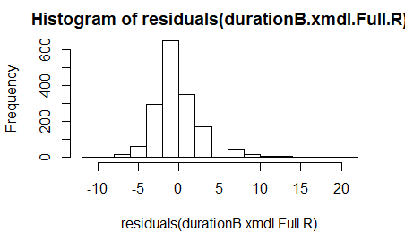

```r
hist(residuals(durationB.xmdl.Full.R))
```

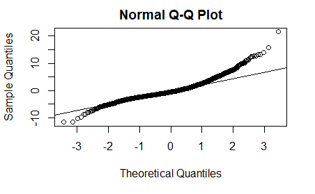

```r
qqnorm(residuals(durationB.xmdl.Full.R)); qqline(residuals(durationB.xmdl.Full.R))
```

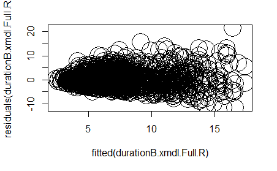

```r
plot(fitted(durationB.xmdl.Full.R),residuals(durationB.xmdl.Full.R), cex = 4)
```

##### 5.1.4.2.3 Summary of model

```r
summary(durationB.xmdl.Full.R)
```

```
Linear mixed model fit by REML. t-tests use Satterthwaite's method [
lmerModLmerTest]
Formula:
durationBurst ~ voiced.unvoiced_c + singGem_c + sex_c + vowelLength_c +
    syllType_c + place_c + (voiced.unvoiced_c + singGem_c + vowelLength_c +
    syllType_c + place_c || speaker) + (1 | wordTarget)
   Data: geminationVOT
Control:
lmerControl(optimizer = "bobyqa", optCtrl = list(maxfun = 1e+05))

REML criterion at convergence: 9099.8

Scaled residuals:
    Min      1Q  Median      3Q     Max
-3.6555 -0.5779 -0.1718  0.4141  6.7797

Random effects:
 Groups     Name              Variance Std.Dev.
 wordTarget (Intercept)        0.47150 0.6867
 speaker    place_c            4.96529 2.2283
 speaker.1  syllType_c         0.03274 0.1810
 speaker.2  vowelLength_c      0.18264 0.4274
 speaker.3  singGem_c          0.00000 0.0000
 speaker.4  voiced.unvoiced_c  0.87766 0.9368
 speaker.5  (Intercept)        1.74348 1.3204
 Residual                     10.18220 3.1910
Number of obs: 1731, groups:  wordTarget, 98; speaker, 20

Fixed effects:
                  Estimate Std. Error      df t value Pr(>|t|)
(Intercept)         8.8508     0.3488 26.1896  25.372  < 2e-16 ***
voiced.unvoiced_c  -2.1172     0.3277 33.2882  -6.462 2.40e-07 ***
singGem_c           0.9949     0.2333 92.1656   4.264 4.86e-05 ***
sex_c               1.0501     0.6258 17.5100   1.678    0.111
vowelLength_c       0.3432     0.2572 38.4606   1.334    0.190
syllType_c          0.4512     0.3038 48.9295   1.485    0.144
place_c             4.1499     0.5979 26.5279   6.941 2.04e-07 ***
---
Signif. codes:  0 ‘***’ 0.001 ‘**’ 0.01 ‘*’ 0.05 ‘.’ 0.1 ‘ ’ 1

Correlation of Fixed Effects:
            (Intr) vcd.n_ sngGm_ sex_c  vwlLn_ syllT_
vocd.nvcd_c  0.080
singGem_c   -0.141 -0.038
sex_c       -0.009 -0.002  0.003
vowlLngth_c  0.161 -0.109  0.080  0.002
syllType_c   0.316  0.032 -0.384 -0.001  0.260
place_c      0.159  0.225 -0.007 -0.007 -0.031  0.018
```

#### 5.1.4.3 Figures

The figure presented below, uses the predicted (or fitted) values; these are the values *adjusted* by the statistical model. These take into account the random effects’ structure as well as the fixed effects’ structure.

##### 5.1.4.3.1 Using “predict”

The following code is used to record the predicted (or fitted) values into the same data-frame. This will then be used to plot the results of the model

```r
geminationVOT$fitted_durationBurst <- predict(lmer(durationBurst~voiced.unvoiced_c+singGem_c+sex_c+vowelLength_c+syllType_c+place_c+
                                (voiced.unvoiced_c+singGem_c+vowelLength_c+syllType_c+place_c||speaker)+(1|wordTarget),
                              data = geminationVOT,na.action=na.exclude,
                              REML=T,
                              control = lmerControl(optimizer = "bobyqa",optCtrl=list(maxfun=1e5)))
)
```

##### 5.1.4.3.2 Plotting the results

We use “ggplot2” to plot the results. This will use the “predicted” (or fitted) values adjusted by our statistical model. The dashed lines *within* the boxplots are the mean values; the median is marked by the horizontal straight lines.

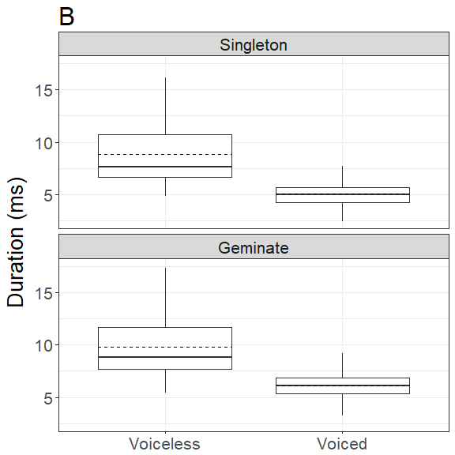

```r
labels <- c(singleton = "Singleton", geminate = "Geminate")
ggdurBByVoice <- ggplot(geminationVOT, aes(y=fitted_durationBurst, x=voiced.unvoiced)) +
  geom_boxplot(outlier.colour = "NA",na.rm=TRUE) +
  stat_summary(fun.y = mean, geom = "errorbar", aes(ymax = ..y.., ymin = ..y..),
               width = .75, linetype = "dashed") +
  ylab(expression(paste("Duration (ms)"))) + labs(title = "B") +
  coord_cartesian(ylim = c(2.5,17.5)) +
  theme_set(theme_bw()) + theme(text=element_text(size=20)) +
  theme(axis.title.x = element_blank()) + theme(legend.title=element_blank()) +
  scale_x_discrete(breaks=levels(geminationVOT$voiced.unvoiced), labels=c("Voiceless","Voiced")) +
  facet_wrap(~singGem,ncol=1,labeller=labeller(singGem = labels))
ggdurBByVoice
```

#### 5.1.4.4 Pairwise comparisons

After running our statistical model above, we wanted to evaluate whether the differences observed between “voicing” and “gemination” is statistically significant (or not). We present the means and standard deviations for each of the four-way contrast based on the predicted (or fitted) values.

##### 5.1.4.4.1 Descriptive statistics

The predicted means and SDs of the duration of the Burst phase are provided below. As can be seen, there are already differences observed related to both “voicing” and “gemination”.

```r
# using "dplyr"
geminationVOT %>% group_by(singGem:voiced.unvoiced) %>% summarise(mean(fitted_durationBurst,na.rm = T), sd(fitted_durationBurst,na.rm = T))
```

| singGem:voiced.unvoiced | mean(fitted_durationBurst, na.rm = T) | sd(fitted_durationBurst, na.rm = T) |
| --- | --- | --- |
| singleton:voiceless | 8.832396 | 2.673174 |
| singleton:voiced | 5.031018 | 1.115101 |
| geminate:voiceless | 9.789074 | 2.691247 |
| geminate:voiced | 6.118367 | 1.164192 |

##### 5.1.4.4.2 Pairwise t-test with FDR corrections

We used the pairwise t-test as available in base R. The input was the predicted (or fitted) values as adjusted by our statistical model. It was not possible to directly use our statistical model’s output to compare models, given that our LMM model was looking at overall change as a main effect rather than as a simple effect’s model. This is why we have used the predicted (or fitted) values as adjusted by our statistical model; the results are the same if we were to use the “actual” results rather than the predicted ones. We used FDR (for False Discovery Rate) correction for multiple comparisons as this allowed for correcting for bias in the differences in doing multiple comparisons.

```r
pairwise.t.test(geminationVOT$fitted_durationBurst, geminationVOT$singGem:geminationVOT$voiced.unvoiced, p.adj = "fdr")
```

```
    Pairwise comparisons using t tests with pooled SD

data:  geminationVOT$fitted_durationBurst and geminationVOT$singGem:geminationVOT$voiced.unvoiced

                   singleton:voiceless singleton:voiced
singleton:voiced   <2e-16              -
geminate:voiceless 6e-11               <2e-16
geminate:voiced    <2e-16              <2e-16
                   geminate:voiceless
singleton:voiced   -
geminate:voiceless -
geminate:voiced    <2e-16

P value adjustment method: fdr
```

### 5.1.5 Duration of the Aspiration phase (Asp)

#### 5.1.5.1 Model specification

We run three models. For model comparisons, we are required to use Maximum Likelihood (ML) on both Optimal and Null models (by adding REML=F). Then we run a second Optimal models with Restricted Maximum Likelihood (REML), to obtain the coefficients (by adding REML=T)

##### 5.1.5.1.1 Optimal model (ML)

```r
durationAsp.xmdl.Full.M <- lmer(durationAsp~voiced.unvoiced_c+singGem_c+sex_c+vowelLength_c+syllType_c+place_c+
                                (voiced.unvoiced_c+singGem_c+vowelLength_c+syllType_c+place_c||speaker)+(1|wordTarget),
                              data = geminationVOT,na.action=na.exclude,
                              REML=F,
                              control = lmerControl(optimizer = "bobyqa",optCtrl=list(maxfun=1e5)))
```

##### 5.1.5.1.2 Optimal model (REML)

```r
durationAsp.xmdl.Full.R <- lmer(durationAsp~voiced.unvoiced_c+singGem_c+sex_c+vowelLength_c+syllType_c+place_c+
                                (voiced.unvoiced_c+singGem_c+vowelLength_c+syllType_c+place_c||speaker)+(1|wordTarget),
                              data = geminationVOT,na.action=na.exclude,
                              REML=T,
                              control = lmerControl(optimizer = "bobyqa",optCtrl=list(maxfun=1e5)))
```

##### 5.1.5.1.3 Null model (ML)

```r
durationAsp.xmdl.Null.M <- lmer(durationAsp~1+
                                (voiced.unvoiced_c+singGem_c+vowelLength_c+syllType_c+place_c||speaker)+(1|wordTarget),
                              data = geminationVOT,na.action=na.exclude,
                              REML=F,
                              control = lmerControl(optimizer = "bobyqa",optCtrl=list(maxfun=1e5)))
```

#### 5.1.5.2 Results of our model

##### 5.1.5.2.1 Model comparisons

```r
anova(durationAsp.xmdl.Null.M,durationAsp.xmdl.Full.M)
```

```
Data: geminationVOT
Models:
durationAsp.xmdl.Null.M: durationAsp ~ 1 + (voiced.unvoiced_c + singGem_c + vowelLength_c +
durationAsp.xmdl.Null.M:     syllType_c + place_c || speaker) + (1 | wordTarget)
durationAsp.xmdl.Full.M: durationAsp ~ voiced.unvoiced_c + singGem_c + sex_c + vowelLength_c +
durationAsp.xmdl.Full.M:     syllType_c + place_c + (voiced.unvoiced_c + singGem_c + vowelLength_c +
durationAsp.xmdl.Full.M:     syllType_c + place_c || speaker) + (1 | wordTarget)
                        Df   AIC   BIC  logLik deviance  Chisq Chi Df
durationAsp.xmdl.Null.M  9 12101 12150 -6041.3    12083
durationAsp.xmdl.Full.M 15 12042 12124 -6005.8    12012 70.961      6
                        Pr(>Chisq)
durationAsp.xmdl.Null.M
durationAsp.xmdl.Full.M  2.597e-13 ***
---
Signif. codes:  0 ‘***’ 0.001 ‘**’ 0.01 ‘*’ 0.05 ‘.’ 0.1 ‘ ’ 1
```

As can be seen, our optimal model improved the model fit.

##### 5.1.5.2.2 Residuals

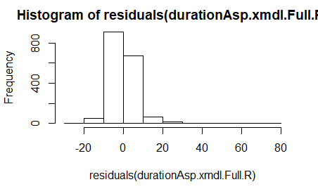

```r
hist(residuals(durationAsp.xmdl.Full.R))
```

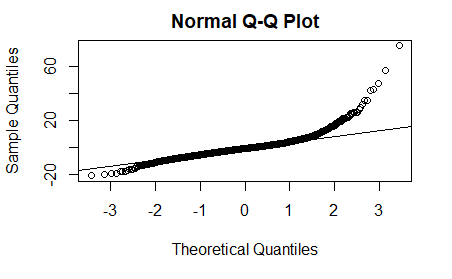

```r
qqnorm(residuals(durationAsp.xmdl.Full.R)); qqline(residuals(durationAsp.xmdl.Full.R))
```

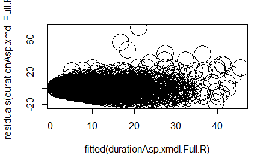

```r
plot(fitted(durationAsp.xmdl.Full.R),residuals(durationAsp.xmdl.Full.R), cex = 4)
```

##### 5.1.5.2.3 Summary of model

```r
summary(durationAsp.xmdl.Full.R)
```

```
Linear mixed model fit by REML. t-tests use Satterthwaite's method [
lmerModLmerTest]
Formula:
durationAsp ~ voiced.unvoiced_c + singGem_c + sex_c + vowelLength_c +
    syllType_c + place_c + (voiced.unvoiced_c + singGem_c + vowelLength_c +
    syllType_c + place_c || speaker) + (1 | wordTarget)
   Data: geminationVOT
Control:
lmerControl(optimizer = "bobyqa", optCtrl = list(maxfun = 1e+05))

REML criterion at convergence: 11996.8

Scaled residuals:
    Min      1Q  Median      3Q     Max
-2.9429 -0.5018 -0.0765  0.3343 10.6900

Random effects:
 Groups     Name              Variance Std.Dev.
 wordTarget (Intercept)        9.673   3.110
 speaker    place_c           20.398   4.516
 speaker.1  syllType_c         1.129   1.062
 speaker.2  vowelLength_c      5.792   2.407
 speaker.3  singGem_c          2.842   1.686
 speaker.4  voiced.unvoiced_c 14.200   3.768
 speaker.5  (Intercept)       18.469   4.298
 Residual                     50.368   7.097
Number of obs: 1731, groups:  wordTarget, 98; speaker, 20

Fixed effects:
                  Estimate Std. Error      df t value Pr(>|t|)
(Intercept)        16.2473     1.1564 31.0503  14.050 5.32e-15 ***
voiced.unvoiced_c  -7.1656     1.2129 47.3349  -5.908 3.62e-07 ***
singGem_c          -1.0769     0.8884 68.9790  -1.212    0.230
sex_c               0.2458     1.9829 17.3256   0.124    0.903
vowelLength_c       4.5724     0.9833 60.1015   4.650 1.87e-05 ***
syllType_c          1.0605     1.0709 75.6114   0.990    0.325
place_c             8.0374     1.5266 50.0638   5.265 2.95e-06 ***
---
Signif. codes:  0 ‘***’ 0.001 ‘**’ 0.01 ‘*’ 0.05 ‘.’ 0.1 ‘ ’ 1

Correlation of Fixed Effects:
            (Intr) vcd.n_ sngGm_ sex_c  vwlLn_ syllT_
vocd.nvcd_c  0.076
singGem_c   -0.134 -0.028
sex_c       -0.005 -0.001  0.002
vowlLngth_c  0.152 -0.091  0.063  0.000
syllType_c   0.327  0.028 -0.340 -0.002  0.231
place_c      0.225  0.287 -0.009 -0.004 -0.037  0.023
```

#### 5.1.5.3 Figures

The figure presented below, uses the predicted (or fitted) values; these are the values *adjusted* by the statistical model. These take into account the random effects’ structure as well as the fixed effects’ structure.

##### 5.1.5.3.1 Using “predict”

The following code is used to record the predicted (or fitted) values into the same data-frame. This will then be used to plot the results of the model

```r
geminationVOT$fitted_durationAsp <- predict(lmer(durationAsp~voiced.unvoiced_c+singGem_c+sex_c+vowelLength_c+syllType_c+place_c+
                                (voiced.unvoiced_c+singGem_c+vowelLength_c+syllType_c+place_c||speaker)+(1|wordTarget),
                              data = geminationVOT,na.action=na.exclude,
                              REML=T,
                              control = lmerControl(optimizer = "bobyqa",optCtrl=list(maxfun=1e5)))
)
```

##### 5.1.5.3.2 Plotting the results

We use “ggplot2” to plot the results. This will use the “predicted” (or fitted) values adjusted by our statistical model. The dashed lines *within* the boxplots are the mean values; the median is marked by the horizontal straight lines.

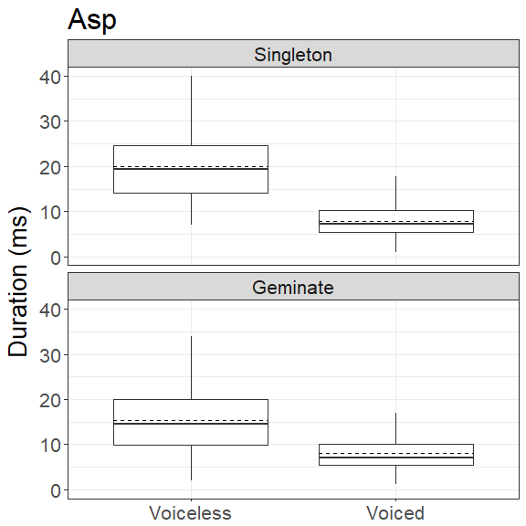

```r
labels <- c(singleton = "Singleton", geminate = "Geminate")
ggdurAspByVoice <- ggplot(geminationVOT, aes(y=fitted_durationAsp, x=voiced.unvoiced)) +
  geom_boxplot(outlier.colour = "NA",na.rm=TRUE) +
  stat_summary(fun.y = mean, geom = "errorbar", aes(ymax = ..y.., ymin = ..y..),
               width = .75, linetype = "dashed") +
  ylab(expression(paste("Duration (ms)"))) + labs(title = "Asp") +
  coord_cartesian(ylim = c(0,40)) +
  theme_set(theme_bw()) + theme(text=element_text(size=20)) +
  theme(axis.title.x = element_blank()) + theme(legend.title=element_blank()) +
  scale_x_discrete(breaks=levels(geminationVOT$voiced.unvoiced), labels=c("Voiceless","Voiced")) +
  facet_wrap(~singGem,ncol=1,labeller=labeller(singGem = labels))
ggdurAspByVoice
```

#### 5.1.5.4 Pairwise comparisons

After running our statistical model above, we wanted to evaluate whether the differences observed between “voicing” and “gemination” is statistically significant (or not). We present the means and standard deviations for each of the four-way contrast based on the predicted (or fitted) values.

##### 5.1.5.4.1 Descriptive statistics

The predicted means and SDs of the duration of the Aspiration phase are provided below. As can be seen, there are already differences observed related to both “voicing” and “gemination”.

```r
# using "dplyr"
geminationVOT %>% group_by(singGem:voiced.unvoiced) %>% summarise(mean(fitted_durationAsp,na.rm = T), sd(fitted_durationAsp,na.rm = T))
```

| singGem:voiced.unvoiced | mean(fitted_durationAsp, na.rm = T) | sd(fitted_durationAsp, na.rm = T) |
| --- | --- | --- |
| singleton:voiceless | 19.971134 | 7.911264 |
| singleton:voiced | 7.888297 | 3.737156 |
| geminate:voiceless | 15.400502 | 7.353787 |
| geminate:voiced | 7.960608 | 3.670839 |

##### 5.1.5.4.2 Pairwise t-test with FDR corrections

We used the pairwise t-test as available in base R. The input was the predicted (or fitted) values as adjusted by our statistical model. It was not possible to directly use our statistical model’s output to compare models, given that our LMM model was looking at overall change as a main effect rather than as a simple effect’s model. This is why we have used the predicted (or fitted) values as adjusted by our statistical model; the results are the same if we were to use the “actual” results rather than the predicted ones. We used FDR (for False Discovery Rate) correction for multiple comparisons as this allowed for correcting for bias in the differences in doing multiple comparisons.

```r
pairwise.t.test(geminationVOT$fitted_durationAsp, geminationVOT$singGem:geminationVOT$voiced.unvoiced, p.adj = "fdr")
```

```
    Pairwise comparisons using t tests with pooled SD

data:  geminationVOT$fitted_durationAsp and geminationVOT$singGem:geminationVOT$voiced.unvoiced

                   singleton:voiceless singleton:voiced
singleton:voiced   <2e-16              -
geminate:voiceless <2e-16              <2e-16
geminate:voiced    <2e-16              0.84
                   geminate:voiceless
singleton:voiced   -
geminate:voiceless -
geminate:voiced    <2e-16

P value adjustment method: fdr
```

### 5.1.6 Duration of the Following Vowel (V2)

#### 5.1.6.1 Model specification

We run three models. For model comparisons, we are required to use Maximum Likelihood (ML) on both Optimal and Null models (by adding REML=F). Then we run a second Optimal models with Restricted Maximum Likelihood (REML), to obtain the coefficients (by adding REML=T)

##### 5.1.6.1.1 Optimal model (ML)

```r
durationV2.xmdl.Full.M <- lmer(duration~voiced.unvoiced_c+singGem_c+sex_c+vowelLength_c+syllType_c+place_c+
                                (voiced.unvoiced_c+singGem_c+vowelLength_c+syllType_c+place_c||speaker)+(1|wordTarget),
                              data = geminationV2,na.action=na.exclude,
                              REML=F,
                              control = lmerControl(optimizer = "bobyqa",optCtrl=list(maxfun=1e5)))
```

##### 5.1.6.1.2 Optimal model (REML)

```r
durationV2.xmdl.Full.R <- lmer(duration~voiced.unvoiced_c+singGem_c+sex_c+vowelLength_c+syllType_c+place_c+
                                (voiced.unvoiced_c+singGem_c+vowelLength_c+syllType_c+place_c||speaker)+(1|wordTarget),
                              data = geminationV2,na.action=na.exclude,
                              REML=T,
                              control = lmerControl(optimizer = "bobyqa",optCtrl=list(maxfun=1e5)))
```

##### 5.1.6.1.3 Null model (ML)

```r
durationV2.xmdl.Null.M <- lmer(duration~1+
                                (voiced.unvoiced_c+singGem_c+vowelLength_c+syllType_c+place_c||speaker)+(1|wordTarget),
                              data = geminationV2,na.action=na.exclude,
                              REML=F,
                              control = lmerControl(optimizer = "bobyqa",optCtrl=list(maxfun=1e5)))
```

#### 5.1.6.2 Results of our model

##### 5.1.6.2.1 Model comparisons

```r
anova(durationV2.xmdl.Null.M,durationV2.xmdl.Full.M)
```

```
Data: geminationV2
Models:
durationV2.xmdl.Null.M: duration ~ 1 + (voiced.unvoiced_c + singGem_c + vowelLength_c +
durationV2.xmdl.Null.M:     syllType_c + place_c || speaker) + (1 | wordTarget)
durationV2.xmdl.Full.M: duration ~ voiced.unvoiced_c + singGem_c + sex_c + vowelLength_c +
durationV2.xmdl.Full.M:     syllType_c + place_c + (voiced.unvoiced_c + singGem_c + vowelLength_c +
durationV2.xmdl.Full.M:     syllType_c + place_c || speaker) + (1 | wordTarget)
                       Df   AIC   BIC  logLik deviance  Chisq Chi Df
durationV2.xmdl.Null.M  9 17047 17097 -8514.7    17029
durationV2.xmdl.Full.M 15 16976 17058 -8472.8    16946 83.673      6
                       Pr(>Chisq)
durationV2.xmdl.Null.M
durationV2.xmdl.Full.M  6.215e-16 ***
---
Signif. codes:  0 ‘***’ 0.001 ‘**’ 0.01 ‘*’ 0.05 ‘.’ 0.1 ‘ ’ 1
```

As can be seen, our optimal model improved the model fit.

##### 5.1.6.2.2 Residuals

We inspect our model below, by looking at the residuals. There are minor deviations observed, due to the nature of our data.

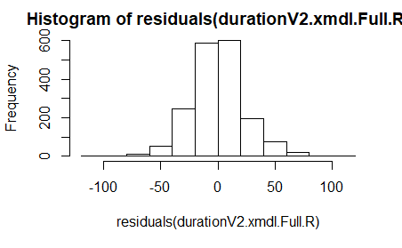

```r
hist(residuals(durationV2.xmdl.Full.R))
```

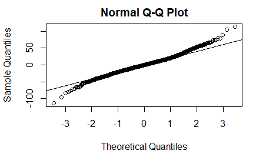

```r
qqnorm(residuals(durationV2.xmdl.Full.R)); qqline(residuals(durationV2.xmdl.Full.R))
```

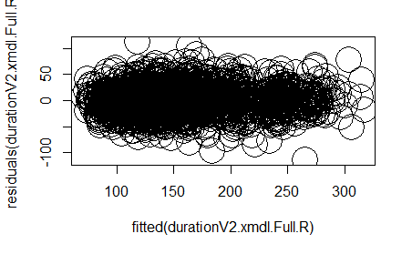

```r
plot(fitted(durationV2.xmdl.Full.R),residuals(durationV2.xmdl.Full.R), cex = 4)
```

##### 5.1.6.2.3 Summary of model

```r
summary(durationV2.xmdl.Full.R)
```

```
Linear mixed model fit by REML. t-tests use Satterthwaite's method [
lmerModLmerTest]
Formula:
duration ~ voiced.unvoiced_c + singGem_c + sex_c + vowelLength_c +
    syllType_c + place_c + (voiced.unvoiced_c + singGem_c + vowelLength_c +
    syllType_c + place_c || speaker) + (1 | wordTarget)
   Data: geminationV2
Control:
lmerControl(optimizer = "bobyqa", optCtrl = list(maxfun = 1e+05))

REML criterion at convergence: 16910

Scaled residuals:
    Min      1Q  Median      3Q     Max
-4.6382 -0.5865 -0.0072  0.5329  4.5934

Random effects:
 Groups     Name              Variance Std.Dev.
 wordTarget (Intercept)       182.26   13.501
 speaker    place_c             0.00    0.000
 speaker.1  syllType_c        583.55   24.157
 speaker.2  vowelLength_c      68.01    8.247
 speaker.3  singGem_c          35.19    5.932
 speaker.4  voiced.unvoiced_c  39.88    6.315
 speaker.5  (Intercept)       644.58   25.389
 Residual                     606.29   24.623
Number of obs: 1793, groups:  wordTarget, 98; speaker, 20

Fixed effects:
                  Estimate Std. Error      df t value Pr(>|t|)
(Intercept)        182.939      6.273  25.530  29.163  < 2e-16 ***
voiced.unvoiced_c    7.465      3.884  91.598   1.922   0.0577 .
singGem_c           15.922      3.582  83.903   4.445 2.68e-05 ***
sex_c              -12.002     11.470  17.999  -1.046   0.3092
vowelLength_c        4.221      3.870  78.721   1.091   0.2788
syllType_c          94.464      6.929  40.672  13.633  < 2e-16 ***
place_c             -3.281      4.753  92.169  -0.690   0.4918
---
Signif. codes:  0 ‘***’ 0.001 ‘**’ 0.01 ‘*’ 0.05 ‘.’ 0.1 ‘ ’ 1

Correlation of Fixed Effects:
            (Intr) vcd.n_ sngGm_ sex_c  vwlLn_ syllT_
vocd.nvcd_c  0.074
singGem_c   -0.105 -0.032
sex_c       -0.001  0.001  0.001
vowlLngth_c  0.122 -0.122  0.065 -0.001
syllType_c   0.161  0.023 -0.225 -0.001  0.156
place_c      0.229  0.498 -0.012  0.000 -0.051  0.020
```

#### 5.1.6.3 Figures

The figure presented below, uses the predicted (or fitted) values; these are the values *adjusted* by the statistical model. These take into account the random effects’ structure as well as the fixed effects’ structure.

##### 5.1.6.3.1 Using “predict”

The following code is used to record the predicted (or fitted) values into the same data-frame. This will then be used to plot the results of the model

```r
geminationV2$fitted_durationV2 <- predict(lmer(duration~voiced.unvoiced_c+singGem_c+sex_c+vowelLength_c+syllType_c+place_c+
                                (voiced.unvoiced_c+singGem_c+vowelLength_c+syllType_c+place_c||speaker)+(1|wordTarget),
                              data = geminationV2,na.action=na.exclude,
                              REML=T,
                              control = lmerControl(optimizer = "bobyqa",optCtrl=list(maxfun=1e5)))
)
```

##### 5.1.6.3.2 Plotting the results

We use “ggplot2” to plot the results. This will use the “predicted” (or fitted) values adjusted by our statistical model. The dashed lines *within* the boxplots are the mean values; the median is marked by the horizontal straight lines.

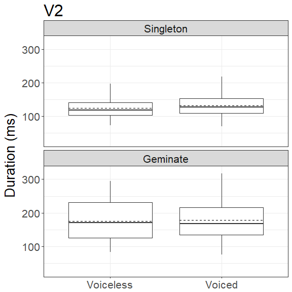

```r
labels <- c(singleton = "Singleton", geminate = "Geminate")
ggdurV2ByVoice <- ggplot(geminationV2, aes(y=fitted_durationV2, x=voiced.unvoiced)) +
  geom_boxplot(outlier.colour = "NA",na.rm=TRUE) +
  stat_summary(fun.y = mean, geom = "errorbar", aes(ymax = ..y.., ymin = ..y..),
               width = .75, linetype = "dashed") +
  ylab(expression(paste("Duration (ms)"))) + labs(title = "V2") +
  coord_cartesian(ylim = c(25,325)) +
  theme_set(theme_bw()) + theme(text=element_text(size=20)) +
  theme(axis.title.x = element_blank()) + theme(legend.title=element_blank()) +
  scale_x_discrete(breaks=levels(geminationV2$voiced.unvoiced), labels=c("Voiceless","Voiced")) +
  facet_wrap(~singGem,ncol=1,labeller=labeller(singGem = labels))
ggdurV2ByVoice
```

#### 5.1.6.4 Pairwise comparisons

After running our statistical model above, we wanted to evaluate whether the differences observed between “voicing” and “gemination” is statistically significant (or not). We present the means and standard deviations for each of the four-way contrast based on the predicted (or fitted) values.

##### 5.1.6.4.1 Descriptive statistics

```r
# using "dplyr"
geminationV2 %>% group_by(singGem:voiced.unvoiced) %>% summarise(mean(fitted_durationV2), sd(fitted_durationV2))
```

| singGem:voiced.unvoiced | mean(fitted_durationV2) | sd(fitted_durationV2) |
| --- | --- | --- |
| singleton:voiceless | 125.1734 | 29.56617 |
| singleton:voiced | 131.7038 | 30.92654 |
| geminate:voiceless | 176.0758 | 55.18708 |
| geminate:voiced | 178.4201 | 52.78116 |

##### 5.1.6.4.2 Pairwise t-test with FDR corrections

We used the pairwise t-test as available in base R. The input was the predicted (or fitted) values as adjusted by our statistical model. It was not possible to directly use our statistical model’s output to compare models, given that our LMM model was looking at overall change as a main effect rather than as a simple effect’s model. This is why we have used the predicted (or fitted) values as adjusted by our statistical model; the results are the same if we were to use the “actual” results rather than the predicted ones. We used FDR (for False Discovery Rate) correction for multiple comparisons as this allowed for correcting for bias in the differences in doing multiple comparisons.

```r
pairwise.t.test(geminationV2$fitted_durationV2, geminationV2$singGem:geminationV2$voiced.unvoiced, p.adj = "fdr")
```

```
    Pairwise comparisons using t tests with pooled SD

data:  geminationV2$fitted_durationV2 and geminationV2$singGem:geminationV2$voiced.unvoiced

                   singleton:voiceless singleton:voiced
singleton:voiced   0.055               -
geminate:voiceless <2e-16              <2e-16
geminate:voiced    <2e-16              <2e-16
                   geminate:voiceless
singleton:voiced   -
geminate:voiceless -
geminate:voiced    0.416

P value adjustment method: fdr
```

## 5.2 Voicing (msec and %)

### 5.2.1 Positive and Negative VOT (Voicing VOT)

#### 5.2.1.1 Model specification

We run three models. For model comparisons, we are required to use Maximum Likelihood (ML) on both Optimal and Null models (by adding REML=F). Then we run a second Optimal models with Restricted Maximum Likelihood (REML), to obtain the coefficients (by adding REML=T)

##### 5.2.1.1.1 Optimal model (ML)

```r
durationVoiceVOT.xmdl.Full.M <- lmer(VOTDec~voiced.unvoiced_c+singGem_c+sex_c+vowelLength_c+syllType_c+place_c+
                                (voiced.unvoiced_c+singGem_c+vowelLength_c+syllType_c+place_c||speaker)+(1|wordTarget),
                              data = geminationCons,na.action=na.exclude,
                              REML=F,
                              control = lmerControl(optimizer = "bobyqa",optCtrl=list(maxfun=1e5)))
```

##### 5.2.1.1.2 Optimal model (REML)

```r
durationVoiceVOT.xmdl.Full.R <- lmer(VOTDec~voiced.unvoiced_c+singGem_c+sex_c+vowelLength_c+syllType_c+place_c+
                                (voiced.unvoiced_c+singGem_c+vowelLength_c+syllType_c+place_c||speaker)+(1|wordTarget),
                              data = geminationCons,na.action=na.exclude,
                              REML=T,
                              control = lmerControl(optimizer = "bobyqa",optCtrl=list(maxfun=1e5)))
```

##### 5.2.1.1.3 Null model (ML)

```r
durationVoiceVOT.xmdl.Null.M <- lmer(VOTDec~1+
                                (voiced.unvoiced_c+singGem_c+vowelLength_c+syllType_c+place_c||speaker)+(1|wordTarget),
                              data = geminationCons,na.action=na.exclude,
                              REML=F,
                              control = lmerControl(optimizer = "bobyqa",optCtrl=list(maxfun=1e5)))
```

#### 5.2.1.2 Results of our model

##### 5.2.1.2.1 Model comparisons

```r
anova(durationVoiceVOT.xmdl.Null.M,durationVoiceVOT.xmdl.Full.M)
```

```
Data: geminationCons
Models:
durationVoiceVOT.xmdl.Null.M: VOTDec ~ 1 + (voiced.unvoiced_c + singGem_c + vowelLength_c +
durationVoiceVOT.xmdl.Null.M:     syllType_c + place_c || speaker) + (1 | wordTarget)
durationVoiceVOT.xmdl.Full.M: VOTDec ~ voiced.unvoiced_c + singGem_c + sex_c + vowelLength_c +
durationVoiceVOT.xmdl.Full.M:     syllType_c + place_c + (voiced.unvoiced_c + singGem_c + vowelLength_c +
durationVoiceVOT.xmdl.Full.M:     syllType_c + place_c || speaker) + (1 | wordTarget)
                             Df   AIC   BIC  logLik deviance Chisq
durationVoiceVOT.xmdl.Null.M  9 19206 19256 -9594.1    19188
durationVoiceVOT.xmdl.Full.M 15 19123 19206 -9546.5    19093 95.02
                             Chi Df Pr(>Chisq)
durationVoiceVOT.xmdl.Null.M
durationVoiceVOT.xmdl.Full.M      6  < 2.2e-16 ***
---
Signif. codes:  0 ‘***’ 0.001 ‘**’ 0.01 ‘*’ 0.05 ‘.’ 0.1 ‘ ’ 1
```

As can be seen, our optimal model improved the model fit.

##### 5.2.1.2.2 Residuals

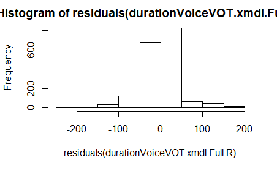

```r
hist(residuals(durationVoiceVOT.xmdl.Full.R))
```

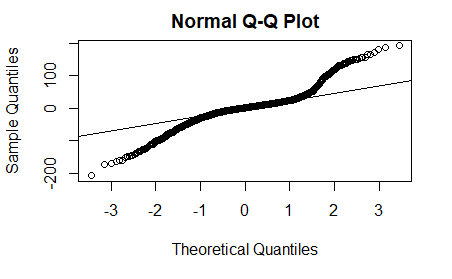

```r
qqnorm(residuals(durationVoiceVOT.xmdl.Full.R)); qqline(residuals(durationVoiceVOT.xmdl.Full.R))
```

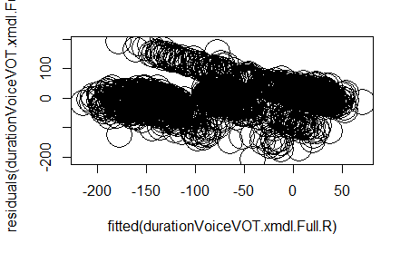

```r
plot(fitted(durationVoiceVOT.xmdl.Full.R),residuals(durationVoiceVOT.xmdl.Full.R), cex = 4)
```

##### 5.2.1.2.3 Summary of model

```r
summary(durationVoiceVOT.xmdl.Full.R)
```

```
Linear mixed model fit by REML. t-tests use Satterthwaite's method [
lmerModLmerTest]
Formula:
VOTDec ~ voiced.unvoiced_c + singGem_c + sex_c + vowelLength_c +
    syllType_c + place_c + (voiced.unvoiced_c + singGem_c + vowelLength_c +
    syllType_c + place_c || speaker) + (1 | wordTarget)
   Data: geminationCons
Control:
lmerControl(optimizer = "bobyqa", optCtrl = list(maxfun = 1e+05))

REML criterion at convergence: 19053.3

Scaled residuals:
    Min      1Q  Median      3Q     Max
-4.5542 -0.3456  0.0334  0.3465  4.2393

Random effects:
 Groups     Name              Variance Std.Dev.
 wordTarget (Intercept)        520.21  22.808
 speaker    place_c             73.92   8.598
 speaker.1  syllType_c           0.00   0.000
 speaker.2  vowelLength_c      111.91  10.579
 speaker.3  singGem_c          340.41  18.450
 speaker.4  voiced.unvoiced_c  627.86  25.057
 speaker.5  (Intercept)        331.50  18.207
 Residual                     2085.69  45.669
Number of obs: 1793, groups:  wordTarget, 98; speaker, 20

Fixed effects:
                  Estimate Std. Error       df t value Pr(>|t|)
(Intercept)        -42.308      6.127   60.677  -6.905 3.46e-09 ***
voiced.unvoiced_c -115.230      8.364   55.606 -13.776  < 2e-16 ***
singGem_c          -45.268      7.046   66.785  -6.425 1.62e-08 ***
sex_c                6.462      8.521   17.678   0.758   0.4582
vowelLength_c       10.904      6.300   82.187   1.731   0.0872 .
syllType_c           5.191      7.442   92.022   0.697   0.4873
place_c              6.701      8.383   84.233   0.799   0.4263
---
Signif. codes:  0 ‘***’ 0.001 ‘**’ 0.01 ‘*’ 0.05 ‘.’ 0.1 ‘ ’ 1

Correlation of Fixed Effects:
            (Intr) vcd.n_ sngGm_ sex_c  vwlLn_ syllT_
vocd.nvcd_c  0.104
singGem_c   -0.160 -0.022
sex_c       -0.004  0.001  0.001
vowlLngth_c  0.227 -0.103  0.060  0.000
syllType_c   0.450  0.029 -0.313  0.000  0.263
place_c      0.392  0.386 -0.010 -0.002 -0.052  0.030
```

#### 5.2.1.3 Figures

The figure presented below, uses the predicted (or fitted) values; these are the values *adjusted* by the statistical model. These take into account the random effects’ structure as well as the fixed effects’ structure.

##### 5.2.1.3.1 Using “predict”

The following code is used to record the predicted (or fitted) values into the same data-frame. This will then be used to plot the results of the model

```r
geminationCons$fitted_VoiceVOT <- predict(lmer(VOTDec~voiced.unvoiced_c+singGem_c+sex_c+vowelLength_c+syllType_c+place_c+
                                (voiced.unvoiced_c+singGem_c+vowelLength_c+syllType_c+place_c||speaker)+(1|wordTarget),
                              data = geminationCons,na.action=na.exclude,
                              REML=T,
                              control = lmerControl(optimizer = "bobyqa",optCtrl=list(maxfun=1e5)))
)
```

##### 5.2.1.3.2 Plotting the results

We use “ggplot2” to plot the results. This will use the “predicted” (or fitted) values adjusted by our statistical model. The dashed lines *within* the boxplots are the mean values; the median is marked by the horizontal straight lines.

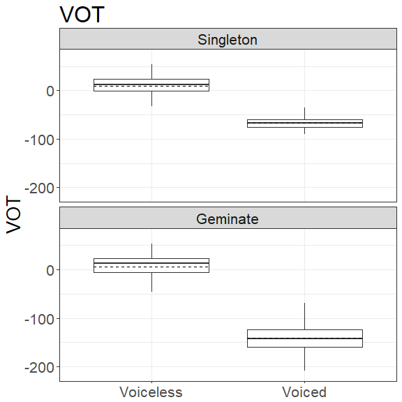

```r
labels <- c(singleton = "Singleton", geminate = "Geminate")
ggVoiceVOTByVoice <- ggplot(geminationCons, aes(y=fitted_VoiceVOT, x=voiced.unvoiced)) +
  geom_boxplot(outlier.colour = "NA",na.rm=TRUE) +
  stat_summary(fun.y = mean, geom = "errorbar", aes(ymax = ..y.., ymin = ..y..),
               width = .75, linetype = "dashed") +
  ylab(expression(paste("VOT"))) + labs(title = "VOT") +
  theme_set(theme_bw()) + theme(text=element_text(size=20)) +
  theme(axis.title.x = element_blank()) + theme(legend.title=element_blank()) +
  scale_x_discrete(breaks=levels(geminationCons$voiced.unvoiced), labels=c("Voiceless","Voiced")) +
  facet_wrap(~singGem,ncol=1,labeller=labeller(singGem = labels))
ggVoiceVOTByVoice
```

#### 5.2.1.4 Pairwise comparisons

After running our statistical model above, we wanted to evaluate whether the differences observed between “voicing” and “gemination” is statistically significant (or not). We present the means and standard deviations for each of the four-way contrast based on the predicted (or fitted) values.

##### 5.2.1.4.1 Descriptive statistics

The predicted means and SDs of the positive and negative VOT (VoiceVOT) are provided below. As can be seen, there are already differences observed related to both “voicing” and “gemination”.

```r
# using "dplyr"
geminationCons %>% group_by(singGem:voiced.unvoiced) %>% summarise(mean(fitted_VoiceVOT), sd(fitted_VoiceVOT))
```

| singGem:voiced.unvoiced | mean(fitted_VoiceVOT) | sd(fitted_VoiceVOT) |
| --- | --- | --- |
| singleton:voiceless | 8.701150 | 23.26063 |
| singleton:voiced | -67.036891 | 11.90670 |
| geminate:voiceless | 5.305812 | 29.69317 |
| geminate:voiced | -140.654225 | 28.60634 |

##### 5.2.1.4.2 Pairwise t-test with FDR corrections

We used the pairwise t-test as available in base R. The input was the predicted (or fitted) values as adjusted by our statistical model. It was not possible to directly use our statistical model’s output to compare models, given that our LMM model was looking at overall change as a main effect rather than as a simple effect’s model. This is why we have used the predicted (or fitted) values as adjusted by our statistical model; the results are the same if we were to use the “actual” results rather than the predicted ones. We used FDR (for False Discovery Rate) correction for multiple comparisons as this allowed for correcting for bias in the differences in doing multiple comparisons.

```r
pairwise.t.test(geminationCons$fitted_VoiceVOT, geminationCons$singGem:geminationCons$voiced.unvoiced, p.adj = "fdr")
```

```
    Pairwise comparisons using t tests with pooled SD

data:  geminationCons$fitted_VoiceVOT and geminationCons$singGem:geminationCons$voiced.unvoiced

                   singleton:voiceless singleton:voiced
singleton:voiced   <2e-16              -
geminate:voiceless 0.064               <2e-16
geminate:voiced    <2e-16              <2e-16
                   geminate:voiceless
singleton:voiced   -
geminate:voiceless -
geminate:voiced    <2e-16

P value adjustment method: fdr
```

### 5.2.2 Proportion of voicing in the closure duration (% Voicing CD)

#### 5.2.2.1 Model specification

We run three models. For model comparisons, we are required to use Maximum Likelihood (ML) on both Optimal and Null models (by adding REML=F). Then we run a second Optimal models with Restricted Maximum Likelihood (REML), to obtain the coefficients (by adding REML=T)

##### 5.2.2.1.1 Optimal model (ML)

```r
durationPropVoiceCD.xmdl.Full.M <- lmer(durationVoicedPerc~voiced.unvoiced_c+singGem_c+sex_c+vowelLength_c+syllType_c+place_c+
                                (voiced.unvoiced_c+singGem_c+vowelLength_c+syllType_c+place_c||speaker)+(1|wordTarget),
                              data = geminationCons,na.action=na.exclude,
                              REML=F,
                              control = lmerControl(optimizer = "bobyqa",optCtrl=list(maxfun=1e5)))
```

##### 5.2.2.1.2 Optimal model (REML)

```r
durationPropVoiceCD.xmdl.Full.R <- lmer(durationVoicedPerc~voiced.unvoiced_c+singGem_c+sex_c+vowelLength_c+syllType_c+place_c+
                                (voiced.unvoiced_c+singGem_c+vowelLength_c+syllType_c+place_c||speaker)+(1|wordTarget),
                              data = geminationCons,na.action=na.exclude,
                              REML=T,
                              control = lmerControl(optimizer = "bobyqa",optCtrl=list(maxfun=1e5)))
```

##### 5.2.2.1.3 Null model (ML)

```r
durationPropVoiceCD.xmdl.Null.M <- lmer(durationVoicedPerc~1+
                                (voiced.unvoiced_c+singGem_c+vowelLength_c+syllType_c+place_c||speaker)+(1|wordTarget),
                              data = geminationCons,na.action=na.exclude,
                              REML=F,
                              control = lmerControl(optimizer = "bobyqa",optCtrl=list(maxfun=1e5)))
```

#### 5.2.2.2 Results of our model

##### 5.2.2.2.1 Model comparisons

```r
anova(durationPropVoiceCD.xmdl.Null.M,durationPropVoiceCD.xmdl.Full.M)
```

```
Data: geminationCons
Models:
durationPropVoiceCD.xmdl.Null.M: durationVoicedPerc ~ 1 + (voiced.unvoiced_c + singGem_c + vowelLength_c +
durationPropVoiceCD.xmdl.Null.M:     syllType_c + place_c || speaker) + (1 | wordTarget)
durationPropVoiceCD.xmdl.Full.M: durationVoicedPerc ~ voiced.unvoiced_c + singGem_c + sex_c +
durationPropVoiceCD.xmdl.Full.M:     vowelLength_c + syllType_c + place_c + (voiced.unvoiced_c +
durationPropVoiceCD.xmdl.Full.M:     singGem_c + vowelLength_c + syllType_c + place_c || speaker) +
durationPropVoiceCD.xmdl.Full.M:     (1 | wordTarget)
                                Df   AIC   BIC  logLik deviance  Chisq
durationPropVoiceCD.xmdl.Null.M  9 15646 15696 -7814.1    15628
durationPropVoiceCD.xmdl.Full.M 15 15544 15626 -7756.9    15514 114.35
                                Chi Df Pr(>Chisq)
durationPropVoiceCD.xmdl.Null.M
durationPropVoiceCD.xmdl.Full.M      6  < 2.2e-16 ***
---
Signif. codes:  0 ‘***’ 0.001 ‘**’ 0.01 ‘*’ 0.05 ‘.’ 0.1 ‘ ’ 1
```

As can be seen, our optimal model improved the model fit.

##### 5.2.2.2.2 Residuals

We inspect our model below, by looking at the residuals. There are minor deviations observed, due to the nature of our data.

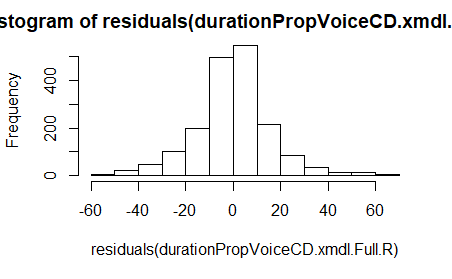

```r
hist(residuals(durationPropVoiceCD.xmdl.Full.R))
```

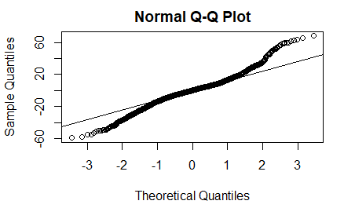

```r
qqnorm(residuals(durationPropVoiceCD.xmdl.Full.R)); qqline(residuals(durationPropVoiceCD.xmdl.Full.R))
```

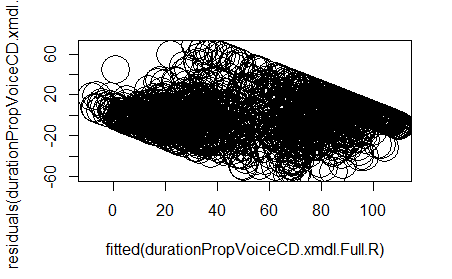

```r
plot(fitted(durationPropVoiceCD.xmdl.Full.R),residuals(durationPropVoiceCD.xmdl.Full.R), cex = 4)
```

##### 5.2.2.2.3 Summary of model

```r
summary(durationPropVoiceCD.xmdl.Full.R)
```

```
Linear mixed model fit by REML. t-tests use Satterthwaite's method [
lmerModLmerTest]
Formula: durationVoicedPerc ~ voiced.unvoiced_c + singGem_c + sex_c +
    vowelLength_c + syllType_c + place_c + (voiced.unvoiced_c +
    singGem_c + vowelLength_c + syllType_c + place_c || speaker) +
    (1 | wordTarget)
   Data: geminationCons
Control:
lmerControl(optimizer = "bobyqa", optCtrl = list(maxfun = 1e+05))

REML criterion at convergence: 15489.7

Scaled residuals:
    Min      1Q  Median      3Q     Max
-3.4488 -0.4823  0.0168  0.4620  3.9848

Random effects:
 Groups     Name              Variance Std.Dev.
 wordTarget (Intercept)        12.39    3.519
 speaker    place_c            21.39    4.625
 speaker.1  syllType_c         14.54    3.814
 speaker.2  vowelLength_c      29.42    5.424
 speaker.3  singGem_c          22.14    4.706
 speaker.4  voiced.unvoiced_c 228.20   15.106
 speaker.5  (Intercept)        83.35    9.130
 Residual                     294.90   17.173
Number of obs: 1793, groups:  wordTarget, 98; speaker, 20

Fixed effects:
                  Estimate Std. Error      df t value Pr(>|t|)
(Intercept)         58.368      2.261  23.234  25.816  < 2e-16 ***
voiced.unvoiced_c   63.207      3.626  21.977  17.430 2.36e-14 ***
singGem_c          -14.467      1.608  31.848  -8.995 2.96e-10 ***
sex_c               -9.774      4.229  17.935  -2.311  0.03291 *
vowelLength_c       -5.577      1.736  29.878  -3.212  0.00315 **
syllType_c           1.693      1.795  38.294   0.943  0.35139
place_c              5.561      2.020  35.168   2.753  0.00928 **
---
Signif. codes:  0 ‘***’ 0.001 ‘**’ 0.01 ‘*’ 0.05 ‘.’ 0.1 ‘ ’ 1

Correlation of Fixed Effects:
            (Intr) vcd.n_ sngGm_ sex_c  vwlLn_ syllT_
vocd.nvcd_c  0.029
singGem_c   -0.084 -0.010
sex_c       -0.004  0.001  0.001
vowlLngth_c  0.101 -0.039  0.044 -0.001
syllType_c   0.226  0.014 -0.261 -0.002  0.177
place_c      0.200  0.167 -0.008 -0.004 -0.037  0.025
```

#### 5.2.2.3 Figures

The figure presented below, uses the predicted (or fitted) values; these are the values *adjusted* by the statistical model. These take into account the random effects’ structure as well as the fixed effects’ structure.

##### 5.2.2.3.1 Using “predict”

The following code is used to record the predicted (or fitted) values into the same data-frame. This will then be used to plot the results of the model

```r
geminationCons$fitted_PropVoiceCD <- predict(lmer(durationVoicedPerc~voiced.unvoiced_c+singGem_c+sex_c+vowelLength_c+syllType_c+place_c+
                                (voiced.unvoiced_c+singGem_c+vowelLength_c+syllType_c+place_c||speaker)+(1|wordTarget),
                              data = geminationCons,na.action=na.exclude,
                              REML=T,
                              control = lmerControl(optimizer = "bobyqa",optCtrl=list(maxfun=1e5)))
)
```

##### 5.2.2.3.2 Plotting the results

We use “ggplot2” to plot the results. This will use the “predicted” (or fitted) values adjusted by our statistical model. The dashed lines *within* the boxplots are the mean values; the median is marked by the horizontal straight lines.

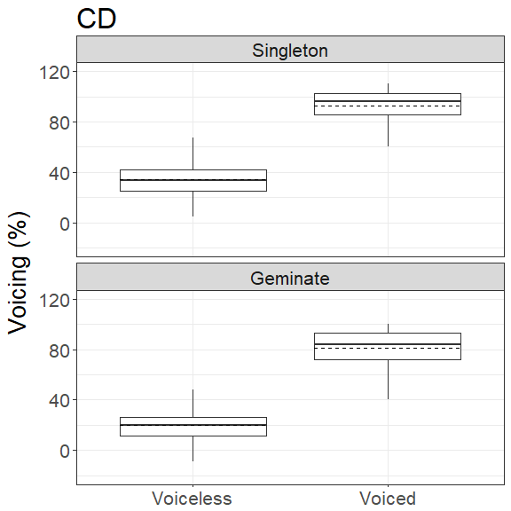

```r
labels <- c(singleton = "Singleton", geminate = "Geminate")
ggPropVoiceCDByVoice <- ggplot(geminationCons, aes(y=fitted_PropVoiceCD, x=voiced.unvoiced)) +
  geom_boxplot(outlier.colour = "NA",na.rm=TRUE) +
  stat_summary(fun.y = mean, geom = "errorbar", aes(ymax = ..y.., ymin = ..y..),
               width = .75, linetype = "dashed") +
  ylab(expression(paste("Voicing (%)"))) + labs(title = "CD") +
  coord_cartesian(ylim = c(-20,120)) +
  theme_set(theme_bw()) + theme(text=element_text(size=20)) +
  theme(axis.title.x = element_blank()) + theme(legend.title=element_blank()) +
  scale_x_discrete(breaks=levels(geminationCons$voiced.unvoiced), labels=c("Voiceless","Voiced")) +
  facet_wrap(~singGem,ncol=1,labeller=labeller(singGem = labels))
ggPropVoiceCDByVoice
```

#### 5.2.2.4 Pairwise comparisons

After running our statistical model above, we wanted to evaluate whether the differences observed between “voicing” and “gemination” is statistically significant (or not). We present the means and standard deviations for each of the four-way contrast based on the predicted (or fitted) values.

##### 5.2.2.4.1 Descriptive statistics

The predicted means and SDs of the Proportion of voicing in the closure duration (% Voicing CD) are provided below. As can be seen, there are already differences observed related to both “voicing” and “gemination”.

```r
# using "dplyr"
geminationCons %>% group_by(singGem:voiced.unvoiced) %>% summarise(mean(fitted_PropVoiceCD), sd(fitted_PropVoiceCD))
```

| singGem:voiced.unvoiced | mean(fitted_PropVoiceCD) | sd(fitted_PropVoiceCD) |
| --- | --- | --- |
| singleton:voiceless | 34.34512 | 13.41975 |
| singleton:voiced | 92.63851 | 12.33572 |
| geminate:voiceless | 19.89978 | 12.16867 |
| geminate:voiced | 81.03996 | 13.83565 |

##### 5.2.2.4.2 Pairwise t-test with FDR corrections

We used the pairwise t-test as available in base R. The input was the predicted (or fitted) values as adjusted by our statistical model. It was not possible to directly use our statistical model’s output to compare models, given that our LMM model was looking at overall change as a main effect rather than as a simple effect’s model. This is why we have used the predicted (or fitted) values as adjusted by our statistical model; the results are the same if we were to use the “actual” results rather than the predicted ones. We used FDR (for False Discovery Rate) correction for multiple comparisons as this allowed for correcting for bias in the differences in doing multiple comparisons.

```r
pairwise.t.test(geminationCons$fitted_PropVoiceCD, geminationCons$singGem:geminationCons$voiced.unvoiced, p.adj = "fdr")
```

```
    Pairwise comparisons using t tests with pooled SD

data:  geminationCons$fitted_PropVoiceCD and geminationCons$singGem:geminationCons$voiced.unvoiced

                   singleton:voiceless singleton:voiced
singleton:voiced   <2e-16              -
geminate:voiceless <2e-16              <2e-16
geminate:voiced    <2e-16              <2e-16
                   geminate:voiceless
singleton:voiced   -
geminate:voiceless -
geminate:voiced    <2e-16

P value adjustment method: fdr
```